# Stack Overflow Developer Survey 2021

**Table of Contents**

1. Business Understanding
2. Data Understanding

## Business Understanding

Explore the followings for the role of a Data Scientist and ML Engineer:

1. As developer by profession w/ stats
2. Employment status w/ stats
3. Countries with DS as most common 10 developer type
4. Education level w. stats
5. Techniques for learning to code w/ stats
6. Coding experience w/ stats
7. Most common Org. size, Lang., DB, Platform, webframe, Misc Tech, Tool Tech, Dev Env, OpSys
8. Behavior when get Stuck, Freq. visited SO sites, etc.
9. How active in SO sites vs. other websites
10. Stats: Age, Gender, Trans, Sexuality Ethnicity, Accessibility, MentalHealth

## Data Understanding

```python
import numpy as np
import pandas as pd
import sidetable
import matplotlib.pyplot as plt
import seaborn as sns
import missingno as msno

pd.set_option('display.max_columns', 500)
pd.options.display.float_format = '{:,.2f}'.format

%matplotlib inline
```

```python
df = pd.read_csv('./data/survey_results_public.csv')
print(f'{df.shape[0]} respondents.\n{df.shape[1]} features.')
print()
df.head()
```

```
83439 respondents.
48 features.
```

|  | ResponseId | MainBranch | Employment | Country | US_State | UK_Country | EdLevel | Age1stCode | LearnCode | YearsCode | YearsCodePro | DevType | OrgSize | Currency | CompTotal | CompFreq | LanguageHaveWorkedWith | LanguageWantToWorkWith | DatabaseHaveWorkedWith | DatabaseWantToWorkWith | PlatformHaveWorkedWith | PlatformWantToWorkWith | WebframeHaveWorkedWith | WebframeWantToWorkWith | MiscTechHaveWorkedWith | MiscTechWantToWorkWith | ToolsTechHaveWorkedWith | ToolsTechWantToWorkWith | NEWCollabToolsHaveWorkedWith | … |
| --- | --- | --- | --- | --- | --- | --- | --- | --- | --- | --- | --- | --- | --- | --- | --- | --- | --- | --- | --- | --- | --- | --- | --- | --- | --- | --- | --- | --- | --- | --- |
| 0 | 1 | I am a developer by profession | Independent contractor, freelancer, or self-em... | Slovakia | NaN | NaN | Secondary school (e.g. American high school, G... | 18 - 24 years | Coding Bootcamp;Other online resources (ex: vi... | NaN | NaN | Developer, mobile | 20 to 99 employees | EUR European Euro | 4,800.00 | Monthly | C++;HTML/CSS;JavaScript;Objective-C;PHP;Swift | Swift | PostgreSQL;SQLite | SQLite | NaN | NaN | Laravel;Symfony | NaN | NaN | NaN | NaN | NaN | PHPStorm;Xcode | … |
| 1 | 2 | I am a student who is learning to code | Student, full-time | Netherlands | NaN | NaN | Bachelor’s degree (B.A., B.S., B.Eng., etc.) | 11 - 17 years | Other online resources (ex: videos, blogs, etc... | 7 | NaN | NaN | NaN | NaN | NaN | NaN | JavaScript;Python | NaN | PostgreSQL | NaN | NaN | NaN | Angular;Flask;Vue.js | NaN | Cordova | NaN | Docker;Git;Yarn | Git | Android Studio;IntelliJ;Notepad++;PyCharm | … |
| 2 | 3 | I am not primarily a developer, but I write co... | Student, full-time | Russian Federation | NaN | NaN | Bachelor’s degree (B.A., B.S., B.Eng., etc.) | 11 - 17 years | Other online resources (ex: videos, blogs, etc... | NaN | NaN | NaN | NaN | NaN | NaN | NaN | Assembly;C;Python;R;Rust | Julia;Python;Rust | SQLite | SQLite | Heroku | NaN | Flask | Flask | NumPy;Pandas;TensorFlow;Torch/PyTorch | Keras;NumPy;Pandas;TensorFlow;Torch/PyTorch | NaN | NaN | IPython/Jupyter;PyCharm;RStudio;Sublime Text;V... | … |
| 3 | 4 | I am a developer by profession | Employed full-time | Austria | NaN | NaN | Master’s degree (M.A., M.S., M.Eng., MBA, etc.) | 11 - 17 years | NaN | NaN | NaN | Developer, front-end | 100 to 499 employees | EUR European Euro | NaN | Monthly | JavaScript;TypeScript | JavaScript;TypeScript | NaN | NaN | NaN | NaN | Angular;jQuery | Angular;jQuery | NaN | NaN | NaN | NaN | NaN | … |
| 4 | 5 | I am a developer by profession | Independent contractor, freelancer, or self-em... | United Kingdom of Great Britain and Northern I... | NaN | England | Master’s degree (M.A., M.S., M.Eng., MBA, etc.) | 5 - 10 years | Friend or family member | 17 | 10 | Developer, desktop or enterprise applications;... | Just me - I am a freelancer, sole proprietor, ... | GBP\tPound sterling | NaN | NaN | Bash/Shell;HTML/CSS;Python;SQL | Bash/Shell;HTML/CSS;Python;SQL | Elasticsearch;PostgreSQL;Redis | Cassandra;Elasticsearch;PostgreSQL;Redis | NaN | NaN | Flask | Flask | Apache Spark;Hadoop;NumPy;Pandas | Hadoop;NumPy;Pandas | Docker;Git;Kubernetes;Yarn | Docker;Git;Kubernetes;Yarn | Atom;IPython/Jupyter;Notepad++;PyCharm;Vim | … |

```python
df.dtypes.value_counts()
```

```
object     45
float64     2
int64       1
dtype: int64
```

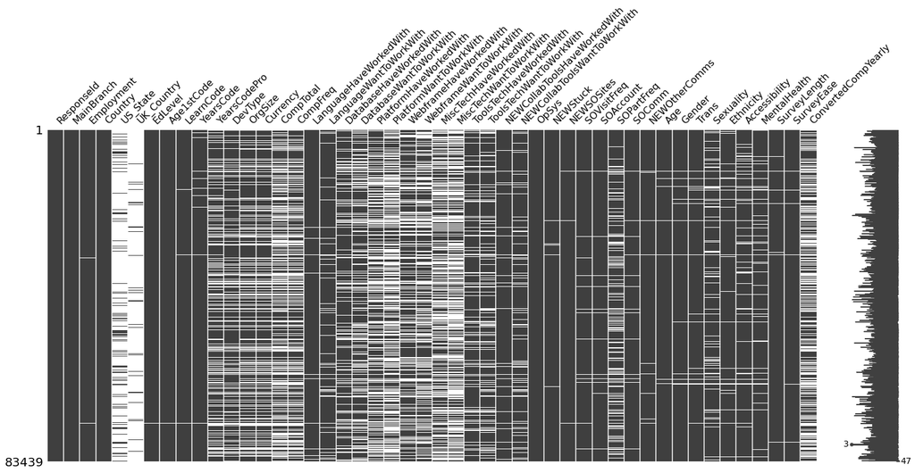

```python
msno.matrix(df);
```

`Here we notice that some columns contains noticeable amount of missing data (NaN) due to the fact that some questions are not applicable to some respondents depending of the sequence of questions and answers they go through. For example, UK_State is only relevant when the respondent is a resident of the UKI.`

```python
# number of distinct/unique values per column
df.nunique().sort_values(ascending=False)
```

```
ResponseId                      83439
LanguageHaveWorkedWith          28690
LanguageWantToWorkWith          27545
NEWCollabToolsHaveWorkedWith    12100
ConvertedCompYearly              8735
DevType                          8626
NEWCollabToolsWantToWorkWith     7026
WebframeHaveWorkedWith           5402
WebframeWantToWorkWith           5113
CompTotal                        3752
DatabaseWantToWorkWith           3137
DatabaseHaveWorkedWith           3072
MiscTechWantToWorkWith           1684
ToolsTechWantToWorkWith          1403
MiscTechHaveWorkedWith           1387
NEWStuck                         1279
ToolsTechHaveWorkedWith           902
LearnCode                         458
Ethnicity                         372
Country                           181
Currency                          146
PlatformWantToWorkWith            126
PlatformHaveWorkedWith            118
US_State                           55
YearsCodePro                       52
YearsCode                          52
MentalHealth                       33
Accessibility                      31
Sexuality                          30
Gender                             16
OrgSize                            10
Employment                          9
Age1stCode                          9
EdLevel                             9
Age                                 8
NEWSOSites                          8
SOComm                              6
SOPartFreq                          6
OpSys                               6
MainBranch                          6
SOVisitFreq                         5
Trans                               4
UK_Country                          4
SOAccount                           3
CompFreq                            3
SurveyLength                        3
SurveyEase                          3
NEWOtherComms                       2
dtype: int64
```

`Notice that columns with high cardinality due to its uniqueness like ResponseId or multiple answer questions, or the option to write answer in own words`

```python
df.select_dtypes('number').skew()
```

```
ResponseId              0.00
CompTotal             217.22
ConvertedCompYearly    30.18
dtype: float64
```

```python
df.select_dtypes('number').kurtosis()
```

```
ResponseId               -1.20
CompTotal                  inf
ConvertedCompYearly   1,681.10
dtype: float64
```

`Notice that CompTotal is very skewed with large tail due to extreme outliers due to high values either by mistake or due to high currency exchange rate with USD.`

```python
# Filter dataset by Data Scientist
ds = df[df['DevType'].str.contains('Data scientist', na=False)].copy()
ds.reset_index(drop=True, inplace=True)
ds[['DevType']].sample(5)
```

|  | DevType |
| --- | --- |
| 162 | Data scientist or machine learning specialist;... |
| 1800 | Developer, desktop or enterprise applications;... |
| 696 | Developer, full-stack;Engineer, data;Data scie... |
| 253 | Developer, full-stack;Data scientist or machin... |
| 3340 | Developer, desktop or enterprise applications;... |

```python
ds.notna().all()[ds.notna().all()]
```

```
ResponseId    True
MainBranch    True
Employment    True
Country       True
DevType       True
dtype: bool
```

```python
print(f'All columns contain missing data except {len(ds.notna().all()[ds.notna().all()])} columns. ')
```

```
All columns contain missing data except 5 columns.
```

```python
ds.notna().all(axis=1).any()
```

```
False
```

```python
print(f'{len(ds.notna().all(axis=1))/len(ds) * 100}% of rows contain missing values.')
```

```
100.0% of rows contain missing values.
```

`All rows contains missing data`

```python
df.isnull().sum().sort_values(ascending=False).head(20)
```

```
UK_Country                 79021
US_State                   68519
MiscTechWantToWorkWith     45418
PlatformWantToWorkWith     41820
ConvertedCompYearly        36595
MiscTechHaveWorkedWith     36384
CompTotal                  36256
WebframeWantToWorkWith     31344
PlatformHaveWorkedWith     31304
CompFreq                   31289
DatabaseWantToWorkWith     25140
OrgSize                    22713
Currency                   22359
YearsCodePro               22223
WebframeHaveWorkedWith     21732
ToolsTechWantToWorkWith    17959
DevType                    16955
SOPartFreq                 15886
DatabaseHaveWorkedWith     13893
ToolsTechHaveWorkedWith    10902
dtype: int64
```

`Top 20 columns by number of missing data.`

```python
df[df.UK_Country.notna()].Country.unique()
```

```
array(['United Kingdom of Great Britain and Northern Ireland'],
      dtype=object)
```

```python
# fig, ax = plt.subplots(figsize=(12,8))
(
    df
    .filter(like='UK_Country')
    .value_counts(normalize=True) * 100
    # .plot.bar(ax=ax, legend=False)
)
```

```
UK_Country
England            88.61
Scotland            7.72
Wales               1.95
Northern Ireland    1.72
dtype: float64
```

```python
df[df.US_State.notna()].Country.unique()
```

```
array(['United States of America'], dtype=object)
```

```python
# fig, ax = plt.subplots(figsize=(12,8))
(
    df
    .filter(like='US_State')
    .value_counts(normalize=True) * 100
    # [:10]
    # .plot.bar(ax=ax, legend=False)
)
```

```
US_State
California                             14.50
Texas                                   6.86
New York                                6.44
Washington                              6.25
Massachusetts                           4.18
Florida                                 4.11
Illinois                                3.93
Colorado                                3.68
Pennsylvania                            3.34
Virginia                                3.04
Ohio                                    3.00
Utah                                    2.78
North Carolina                          2.70
Michigan                                2.55
Oregon                                  2.51
Minnesota                               2.41
Georgia                                 2.39
Maryland                                2.35
New Jersey                              2.33
Wisconsin                               1.78
Arizona                                 1.75
Missouri                                1.54
Indiana                                 1.39
Tennessee                               1.36
Connecticut                             0.86
Iowa                                    0.85
Idaho                                   0.81
Kansas                                  0.80
South Carolina                          0.78
Alabama                                 0.78
Kentucky                                0.74
Nebraska                                0.69
New Hampshire                           0.62
Oklahoma                                0.58
New Mexico                              0.56
District of Columbia                    0.54
Nevada                                  0.52
Louisiana                               0.47
Arkansas                                0.43
Vermont                                 0.40
Maine                                   0.38
Rhode Island                            0.27
South Dakota                            0.24
Montana                                 0.23
Hawaii                                  0.22
Puerto Rico                             0.17
Mississippi                             0.16
North Dakota                            0.15
West Virginia                           0.15
Alaska                                  0.14
Delaware                                0.14
Wyoming                                 0.07
I do not reside in the United States    0.05
Guam                                    0.01
American Samoa                          0.01
dtype: float64
```

### 1. As developer by profession w/ stats

```python
tmp=(
    ds
    .MainBranch
    .value_counts(normalize=True) * 100
    # .head()
)
tmp
```

```
I am a developer by profession                                                  75.19
I am not primarily a developer, but I write code sometimes as part of my work   18.98
I am a student who is learning to code                                           2.90
I used to be a developer by profession, but no longer am                         1.24
I code primarily as a hobby                                                      1.19
None of these                                                                    0.49
Name: MainBranch, dtype: float64
```

- Over 75% of the DS are developers by profession.

### 2. Employment status w/ stats

```python
tmp=(
    ds
    .Employment
    .value_counts(normalize=True) * 100
    # .head()
)
tmp
```

```
Employed full-time                                     79.15
Independent contractor, freelancer, or self-employed   12.57
Employed part-time                                      4.66
Not employed, but looking for work                      3.63
Name: Employment, dtype: float64
```

- Around 80% of the DS are full-time employees.

### 3. Countries with DS as most common 10 developer type

```python
tmp=(
    ds
    .groupby(['Country']).ResponseId
    .count()
    .sort_values(ascending=False)
    [:10]
)
print(f'The top 10 countries by count of DS developers are:')
[f'{i+1}. {c}' for i, c in enumerate(tmp.index.values)]
```

```
The top 10 countries by count of DS developers are:
```

```
['1. United States of America',
 '2. India',
 '3. Germany',
 '4. United Kingdom of Great Britain and Northern Ireland',
 '5. France',
 '6. Canada',
 '7. Brazil',
 '8. Spain',
 '9. Italy',
 '10. Netherlands']
```

### 4. Education level w. stats

```python
tmp=(
    ds
    .groupby(['EdLevel']).ResponseId
    .count()
    .sort_values(ascending=False)
    .pipe(lambda x:x/x.sum()*100)
    .to_frame()
    .rename(columns={'ResponseId':'Perc'})
    .assign(CumPerc = lambda df:df.Perc.cumsum())
    .style.format(formatter={'Perc': "{:.2f}%",
                             'CumPerc':'{:.2f}%'
                          })
)
tmp
```

| EdLevel | Perc | CumPerc |
| --- | --- | --- |
| Master’s degree (M.A., M.S., M.Eng., MBA, etc.) | 40.75% | 40.75% |
| Bachelor’s degree (B.A., B.S., B.Eng., etc.) | 30.82% | 71.57% |
| Other doctoral degree (Ph.D., Ed.D., etc.) | 16.63% | 88.20% |
| Some college/university study without earning a degree | 5.20% | 93.40% |
| Secondary school (e.g. American high school, German Realschule or Gymnasium, etc.) | 2.51% | 95.90% |
| Professional degree (JD, MD, etc.) | 1.66% | 97.56% |
| Associate degree (A.A., A.S., etc.) | 0.98% | 98.55% |
| Primary/elementary school | 0.73% | 99.27% |
| Something else | 0.73% | 100.00% |

- 88% of DS are BSc or MSc or PhD.

### 5. Techniques for learning to code w/ stats

```python
tmp=(
    ds
    .LearnCode.str.split(';', expand=True)
    .stack()
    .value_counts()
    .pipe(lambda x:x/x.sum()*100)
    .to_frame()
    .rename(columns={0:'Perc'})
    .assign(CumPerc = lambda df:df.Perc.cumsum())
    .style.format(formatter={'Perc': "{:.2f}%",
                             'CumPerc':'{:.2f}%'
                          })
)
tmp
```

|  | Perc | CumPerc |
| --- | --- | --- |
| School | 19.21% | 19.21% |
| Books / Physical media | 18.20% | 37.41% |
| Other online resources (ex: videos, blogs, etc) | 18.10% | 55.51% |
| Online Courses or Certification | 14.06% | 69.56% |
| Online Forum | 10.66% | 80.22% |
| Friend or family member | 6.65% | 86.88% |
| Colleague | 6.49% | 93.37% |
| Coding Bootcamp | 3.39% | 96.76% |
| Other (please specify): | 3.24% | 100.00% |

- Over 55% learned coding from school, Books / Physical media and Other online resources (ex: videos, blogs, etc).
- Least means of learning was (surprisingly for me) Coding Bootcamp.

### 6. Coding experience w/ stats

```python
tmp=(
    ds
    [['YearsCode']]
    .replace({r'More':50.5, 'Less':0.5, 'nan':np.nan}, regex=True)
    .dropna()
    .YearsCode
    .astype(float)
    .pipe(lambda x:pd.cut(x, [0,10,20,30,40,50,60]))
    .pipe(lambda x:x.groupby(x))
    .count()
    .pipe(lambda x:x/x.sum()) *100
)
tmp
```

```
YearsCode
(0, 10]    48.76
(10, 20]   31.45
(20, 30]   12.03
(30, 40]    6.04
(40, 50]    1.49
(50, 60]    0.24
Name: YearsCode, dtype: float64
```

- Over 80% of DS have 20 years or less of coding experience including any education with almost 49% with 10 years or less.

```python
tmp=(
    ds
    [['YearsCodePro']]
    .replace({r'More':50.5, 'Less':0.5, 'nan':np.nan}, regex=True)
    .dropna()
    .YearsCodePro
    .astype(float)
    .pipe(lambda x:pd.cut(x, [0,10,20,30,40,50,60]))
    .pipe(lambda x:x.groupby(x))
    .count()
    .pipe(lambda x:x/x.sum()) *100
)
tmp
```

```
YearsCodePro
(0, 10]    73.29
(10, 20]   17.46
(20, 30]    6.77
(30, 40]    1.90
(40, 50]    0.51
(50, 60]    0.08
Name: YearsCodePro, dtype: float64
```

- Over 90% of DS have 20 years or less of professional coding experience NOT including any education with over 73% with 10 years or less.

### 7. Most common Org. size, Lang., DB, Platform, webframe, Misc Tech, Tool Tech, Dev Env, OpSys

#### OrgSize

```python
tmp=(
    ds
    ['OrgSize']
    .pipe(lambda x:x.groupby(x))
    .count()
    # .value_counts()
    .pipe(lambda x:x/x.sum()*100)
    .sort_values(ascending=False)
)
tmp
```

```
OrgSize
20 to 99 employees                                   17.97
10,000 or more employees                             17.36
100 to 499 employees                                 14.35
1,000 to 4,999 employees                             11.80
2 to 9 employees                                     10.30
10 to 19 employees                                    7.75
Just me - I am a freelancer, sole proprietor, etc.    7.09
500 to 999 employees                                  6.02
5,000 to 9,999 employees                              4.74
I don’t know                                          2.63
Name: OrgSize, dtype: float64
```

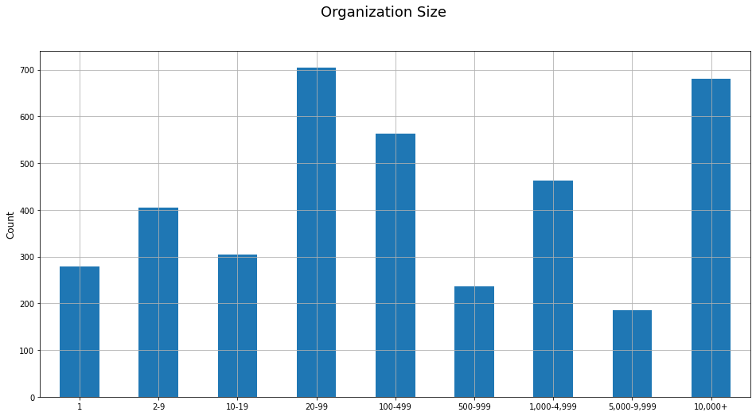

```python
fig, ax = plt.subplots(figsize=(16,8))
tmp=(
    ds
    ['OrgSize']
    .replace({r' employees':'', ' to ':'-', 'I don’t know':np.nan, ' or more':'+',r'Just me.+':'1'}, regex=True)
    .dropna()
    .pipe(lambda x:x.groupby(x))
    .count()
    .loc[['1', '2-9', '10-19', '20-99', '100-499', '500-999', '1,000-4,999', '5,000-9,999', '10,000+', ]]
    .plot(kind='bar', ax=ax, grid=True, rot=0)
)
ax.set_xlabel('')
ax.set_ylabel('Count', fontsize=12)
fig.suptitle('Organization Size', fontsize=18);
```

- Most DS work in mid (20-99, probably startups) to large scale (10k+) organizations

#### Languages

|  | Perc | CumPerc |
| --- | --- | --- |
| Python | 15.87 | 15.87 |
| SQL | 9.80 | 25.68 |
| JavaScript | 8.38 | 34.05 |
| HTML/CSS | 7.38 | 41.43 |
| Bash/Shell | 6.45 | 47.88 |
| C++ | 5.41 | 53.29 |
| Java | 5.08 | 58.37 |
| R | 4.92 | 63.29 |
| C | 4.23 | 67.52 |
| Node.js | 4.08 | 71.60 |
| C# | 3.19 | 74.80 |
| TypeScript | 3.13 | 77.92 |
| PHP | 2.37 | 80.29 |
| Matlab | 2.16 | 82.46 |
| PowerShell | 2.15 | 84.61 |
| Go | 1.56 | 86.17 |
| Scala | 1.29 | 87.46 |
| Rust | 1.26 | 88.72 |
| VBA | 1.26 | 89.98 |
| Julia | 1.09 | 91.07 |
| Assembly | 1.03 | 92.10 |
| Kotlin | 0.94 | 93.05 |
| Ruby | 0.88 | 93.93 |
| Dart | 0.72 | 94.65 |
| Perl | 0.67 | 95.32 |
| Swift | 0.66 | 95.99 |
| Haskell | 0.48 | 96.47 |
| LISP | 0.47 | 96.94 |
| Groovy | 0.47 | 97.41 |
| Clojure | 0.46 | 97.86 |
| Objective-C | 0.43 | 98.29 |
| Delphi | 0.35 | 98.65 |
| F# | 0.32 | 98.96 |
| Elixir | 0.28 | 99.24 |
| COBOL | 0.21 | 99.45 |
| APL | 0.21 | 99.65 |
| Erlang | 0.19 | 99.84 |
| Crystal | 0.16 | 100.00 |

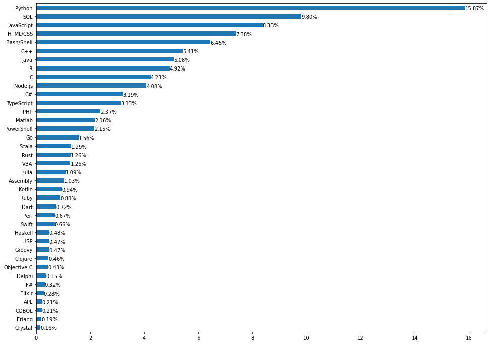

```python
tmp = (
    ds
    ['LanguageHaveWorkedWith']
    .str.split(';', expand=True).stack().reset_index(drop=True)
    .value_counts(ascending=True)
    .pipe(lambda x:x/sum(x)*100)
    .sort_values(ascending=False)
    .to_frame()
    .rename(columns={0:'Perc'})
    .assign(CumPerc = lambda df:df.Perc.cumsum())
)
display(tmp)

fig, ax = plt.subplots(figsize=(16,12))
y =tmp['Perc'].sort_values(ascending=True)
y.plot.barh(ax=ax,)
for i, v in enumerate(y):
    ax.text(v, i-0.25, str(f'{v:.2f}%'), color='black', fontweight='light')
plt.show()
```

- Not surprisingly, Python was the top used language for coding followed by SQL and JavaScript and Bash/Shell constituting around 48%.

#### Database

|  | Perc | CumPerc |
| --- | --- | --- |
| PostgreSQL | 17.11 | 17.11 |
| MySQL | 16.19 | 33.30 |
| SQLite | 13.43 | 46.74 |
| Microsoft SQL Server | 9.62 | 56.36 |
| MongoDB | 9.59 | 65.95 |
| Redis | 6.81 | 72.76 |
| Elasticsearch | 6.23 | 79.00 |
| Oracle | 5.21 | 84.20 |
| MariaDB | 4.93 | 89.13 |
| Firebase | 4.00 | 93.13 |
| DynamoDB | 2.96 | 96.09 |
| Cassandra | 1.92 | 98.01 |
| IBM DB2 | 1.14 | 99.16 |
| Couchbase | 0.84 | 100.00 |

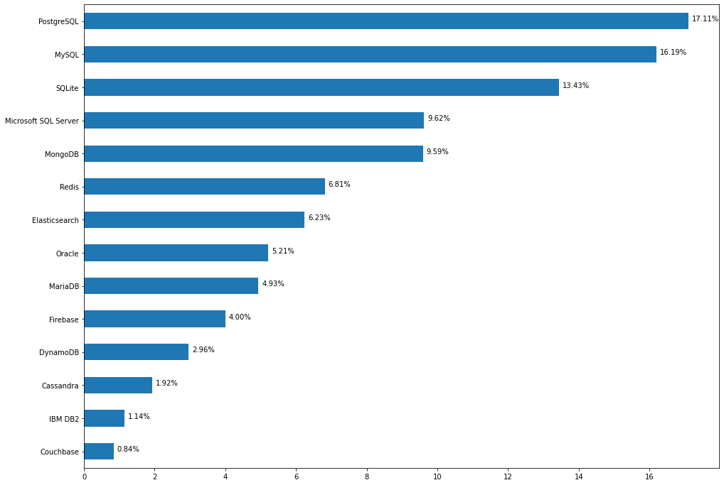

```python
tmp = (
    ds
    ['DatabaseHaveWorkedWith']
    .str.split(';', expand=True).stack().reset_index(drop=True)
    .value_counts(ascending=True)
    .pipe(lambda x:x/sum(x)*100)
    .sort_values(ascending=False)
    .to_frame()
    .rename(columns={0:'Perc'})
    .assign(CumPerc = lambda df:df.Perc.cumsum())
)
display(tmp)

fig, ax = plt.subplots(figsize=(16,12))
y =tmp['Perc'].sort_values(ascending=True)
y.plot.barh(ax=ax,)
for i, v in enumerate(y):
    ax.text(v+0.1, i, str(f'{v:.2f}%'), color='black', fontweight='light')
plt.show()
```

- For Database, over 56% of DS uses PostgreSQL, MySQL, SQLite, and Microsoft SQL Server.

#### Platform

|  | Perc | CumPerc |
| --- | --- | --- |
| AWS | 35.02 | 35.02 |
| Google Cloud Platform | 22.95 | 57.97 |
| Microsoft Azure | 19.01 | 76.98 |
| Heroku | 9.94 | 86.92 |
| DigitalOcean | 8.23 | 95.15 |
| IBM Cloud or Watson | 3.26 | 98.41 |
| Oracle Cloud Infrastructure | 1.59 | 100.00 |

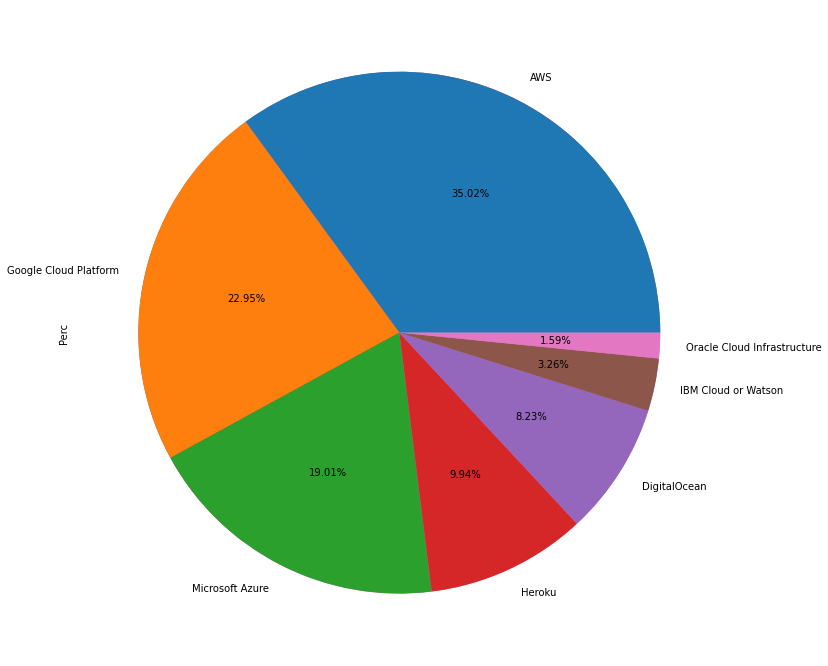

```python
tmp = (
    ds
    ['PlatformHaveWorkedWith']
    .str.split(';', expand=True).stack().reset_index(drop=True)
    .value_counts(ascending=True)
    .pipe(lambda x:x/sum(x)*100)
    .sort_values(ascending=False)
    .to_frame()
    .rename(columns={0:'Perc'})
    .assign(CumPerc = lambda df:df.Perc.cumsum())
)
display(tmp)

fig, ax = plt.subplots(figsize=(16,12))
y =tmp['Perc'].sort_values(ascending=True)
y.plot.pie(ax=ax,labels=None)
ax.get_xaxis().set_visible(False)
frac = tmp.Perc
labels = tmp.index
ax.pie(x=frac, labels=labels, autopct='%1.2f%%')
plt.show()
```

- Amazon and Google cloud services was the platform tools preferred by most of the DS with a percentage of 58%.

#### WebFrame

|  | Perc | CumPerc |
| --- | --- | --- |
| Flask | 17.81 | 17.81 |
| React.js | 11.25 | 29.06 |
| Django | 10.57 | 39.63 |
| jQuery | 10.46 | 50.09 |
| FastAPI | 6.25 | 56.34 |
| Angular | 6.25 | 62.59 |
| Vue.js | 5.88 | 68.47 |
| Express | 5.77 | 74.24 |
| ASP.NET Core | 4.29 | 78.53 |
| ASP.NET | 4.09 | 82.62 |
| Angular.js | 4.00 | 86.62 |
| Spring | 3.99 | 90.61 |
| Laravel | 2.53 | 93.14 |
| Ruby on Rails | 2.09 | 95.23 |
| Symfony | 1.23 | 96.47 |
| Svelte | 1.21 | 97.67 |
| Drupal | 1.20 | 98.87 |
| Gatsby | 1.13 | 100.00 |

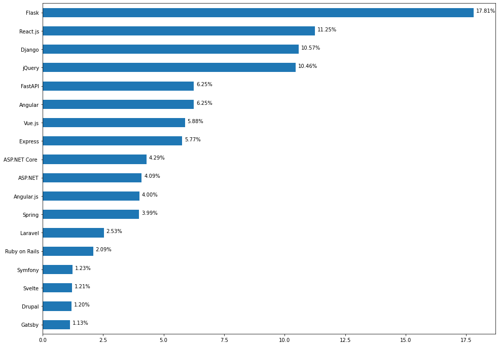

```python
tmp = (
    ds
    ['WebframeHaveWorkedWith']
    .str.split(';', expand=True).stack().reset_index(drop=True)
    .value_counts(ascending=True)
    .pipe(lambda x:x/sum(x)*100)
    .sort_values(ascending=False)
    .to_frame()
    .rename(columns={0:'Perc'})
    .assign(CumPerc = lambda df:df.Perc.cumsum())
)
display(tmp)

fig, ax = plt.subplots(figsize=(16,12))
y =tmp['Perc'].sort_values(ascending=True)
y.plot.barh(ax=ax,)
for i, v in enumerate(y):
    ax.text(v+0.1, i, str(f'{v:.2f}%'), color='black', fontweight='light')
plt.show()
```

- Flask, React.js, Django and jQuery accounted for over 50% of the top web frames used by DS respondents. It was noticed that Flask was the most popular with over 17.8%.

#### MiscTech

|  | Perc | CumPerc |
| --- | --- | --- |
| NumPy | 21.90 | 21.90 |
| Pandas | 20.50 | 42.40 |
| TensorFlow | 13.79 | 56.19 |
| Keras | 10.79 | 66.97 |
| Torch/PyTorch | 10.27 | 77.24 |
| Apache Spark | 4.93 | 82.17 |
| .NET Framework | 3.63 | 85.81 |
| Hadoop | 3.33 | 89.14 |
| .NET Core / .NET 5 | 3.30 | 92.44 |
| Qt | 3.07 | 95.51 |
| React Native | 1.81 | 97.33 |
| Flutter | 1.71 | 99.04 |
| Cordova | 0.96 | 100.00 |

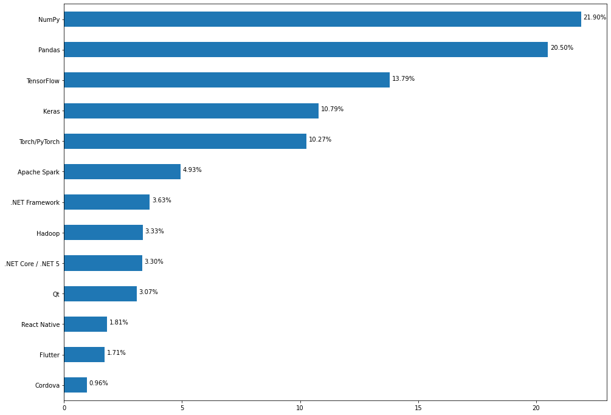

```python
tmp = (
    ds
    ['MiscTechHaveWorkedWith']
    .str.split(';', expand=True).stack().reset_index(drop=True)
    .value_counts(ascending=True)
    .pipe(lambda x:x/sum(x)*100)
    .sort_values(ascending=False)
    .to_frame()
    .rename(columns={0:'Perc'})
    .assign(CumPerc = lambda df:df.Perc.cumsum())
)
display(tmp)

fig, ax = plt.subplots(figsize=(16,12))
y =tmp['Perc'].sort_values(ascending=True)
y.plot.barh(ax=ax,)
for i, v in enumerate(y):
    ax.text(v+0.1, i, str(f'{v:.2f}%'), color='black', fontweight='light')
plt.show()
```

- Not surprisingly, Numpy and Pandas led the way with cumulative percentage of over 42% follow by TensorFlow, Keras and PyTorch/Torch accounting for over 77%.

#### ToolsTech

|  | Perc | CumPerc |
| --- | --- | --- |
| Git | 41.59 | 41.59 |
| Docker | 26.54 | 68.12 |
| Kubernetes | 9.54 | 77.66 |
| Yarn | 4.92 | 82.58 |
| Ansible | 3.67 | 86.26 |
| Terraform | 3.60 | 89.86 |
| Unity 3D | 3.37 | 93.23 |
| Unreal Engine | 1.66 | 94.89 |
| Xamarin | 1.39 | 96.28 |
| Puppet | 1.09 | 97.37 |
| Chef | 0.85 | 98.22 |
| Flow | 0.80 | 99.02 |
| Deno | 0.64 | 99.65 |
| Pulumi | 0.35 | 100.00 |

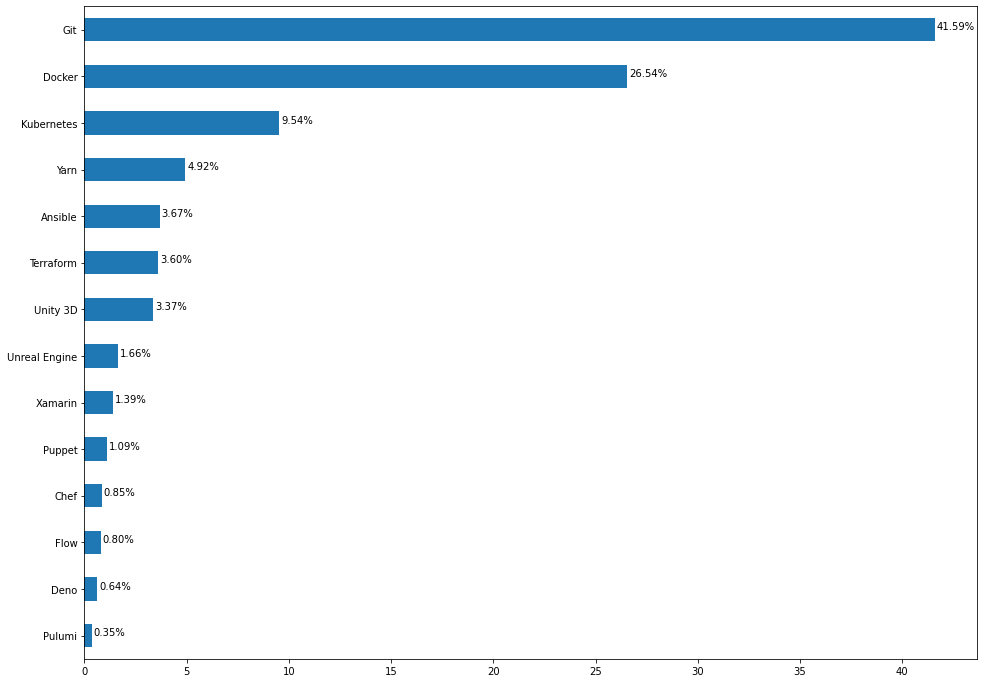

```python
tmp = (
    ds
    ['ToolsTechHaveWorkedWith']
    .str.split(';', expand=True).stack().reset_index(drop=True)
    .value_counts(ascending=True)
    .pipe(lambda x:x/sum(x)*100)
    .sort_values(ascending=False)
    .to_frame()
    .rename(columns={0:'Perc'})
    .assign(CumPerc = lambda df:df.Perc.cumsum())
)
display(tmp)

fig, ax = plt.subplots(figsize=(16,12))
y =tmp['Perc'].sort_values(ascending=True)
y.plot.barh(ax=ax,)
for i, v in enumerate(y):
    ax.text(v+0.1, i, str(f'{v:.2f}%'), color='black', fontweight='light')
plt.show()
```

#### CollabTools

|  | Perc | CumPerc |
| --- | --- | --- |
| Visual Studio Code | 15.96 | 15.96 |
| IPython/Jupyter | 12.92 | 28.88 |
| PyCharm | 10.03 | 38.91 |
| Vim | 7.97 | 46.88 |
| Notepad++ | 7.72 | 54.59 |
| Visual Studio | 5.94 | 60.53 |
| Sublime Text | 5.91 | 66.44 |
| IntelliJ | 5.73 | 72.16 |
| RStudio | 5.41 | 77.58 |
| Android Studio | 3.92 | 81.49 |
| Atom | 3.91 | 85.41 |
| Eclipse | 3.75 | 89.16 |
| Emacs | 2.16 | 91.32 |
| Xcode | 2.10 | 93.42 |
| NetBeans | 1.68 | 95.09 |
| Neovim | 1.36 | 96.45 |
| Webstorm | 1.27 | 97.72 |
| PHPStorm | 1.12 | 98.84 |
| Rider | 0.46 | 99.31 |
| TextMate | 0.36 | 99.67 |
| RubyMine | 0.33 | 100.00 |

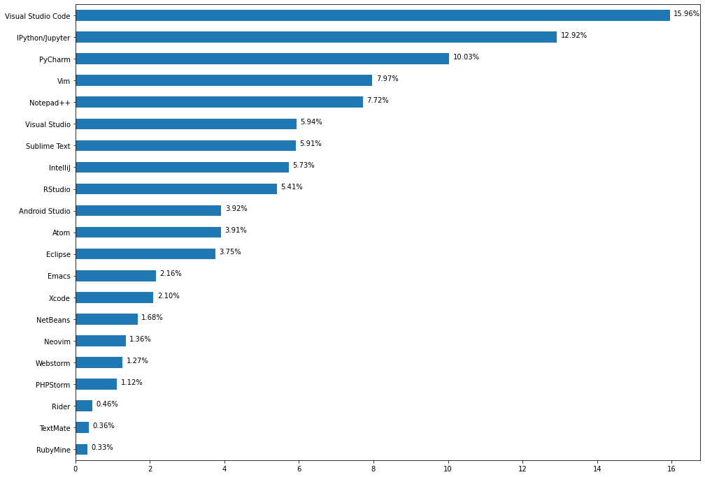

```python
tmp = (
    ds
    ['NEWCollabToolsHaveWorkedWith']
    .str.split(';', expand=True).stack().reset_index(drop=True)
    .value_counts(ascending=True)
    .pipe(lambda x:x/sum(x)*100)
    .sort_values(ascending=False)
    .to_frame()
    .rename(columns={0:'Perc'})
    .assign(CumPerc = lambda df:df.Perc.cumsum())
)
display(tmp)

fig, ax = plt.subplots(figsize=(16,12))
y =tmp['Perc'].sort_values(ascending=True)
y.plot.barh(ax=ax,)
for i, v in enumerate(y):
    ax.text(v+0.1, i, str(f'{v:.2f}%'), color='black', fontweight='light')
plt.show()
```

- I was surprised to know that VSC was the most popular collaborative tool used by DS followed by Jupyter/IPython, PyCharm, Vim and Notepad++ accounting for around 55%. I also did not expect not to see Atom in the top 10 list.

#### OpSys

|  | Perc | CumPerc |
| --- | --- | --- |
| Windows | 37.13 | 37.13 |
| Linux-based | 36.36 | 73.49 |
| MacOS | 21.50 | 94.98 |
| Windows Subsystem for Linux (WSL) | 3.87 | 98.85 |
| Other | 1.15 | 100.00 |

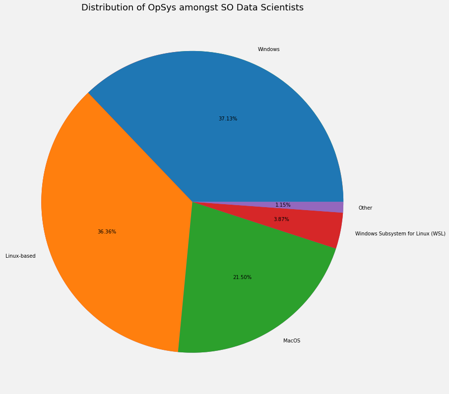

```python
tmp=(
    ds
    .OpSys.replace(dict.fromkeys(['Other (please specify):','BSD'], 'Other'))
    .value_counts(normalize=True)
    .to_frame()
    .mul(100)
    .rename(columns={'OpSys':'Perc'})
    .assign(CumPerc = lambda df:df.Perc.cumsum())
)
display(tmp)

fig, ax = plt.subplots(figsize=(14,14))
y =tmp['Perc'].sort_values(ascending=True)
y.plot.pie(ax=ax,labels=None)
ax.get_xaxis().set_visible(False)
frac = tmp.Perc
labels = tmp.index
ax.pie(x=frac, labels=labels, autopct='%1.2f%%')
ax.get_yaxis().set_visible(False)
ax.set_title('Distribution of OpSys amongst SO Data Scientists', fontsize=18)
fig.set_facecolor('grey')
fig.patch.set_alpha(0.1)
plt.show()
```

- Windows and Linus are the most popular followed by MacOSwith a total share of 95%

### 8. Behavior when get Stuck, Freq. visited SO sites, etc.

#### NEW Stuck

```python
from pprint import  pprint
```

```python
p = ds.NEWStuck.str.split(';', expand=True).stack().reset_index(drop=True).unique()
pprint(p)
```

```
array(['Call a coworker or friend', 'Visit Stack Overflow', 'Google it',
       'Meditate', 'Go for a walk or other physical activity',
       'Do other work and come back later', 'Play games',
       'Watch help / tutorial videos', 'Panic',
       'Visit another developer community (please name):',
       'Other (please specify):'], dtype=object)
```

|  | Perc | CumPerc |
| --- | --- | --- |
| Google it | 22.14 | 22.14 |
| Visit Stack Overflow | 20.54 | 42.69 |
| Do other work and come back later | 12.58 | 55.26 |
| Go for a walk or other physical activity | 10.89 | 66.16 |
| Watch help / tutorial videos | 10.66 | 76.82 |
| Call a coworker or friend | 9.43 | 86.25 |
| Play games | 3.41 | 89.66 |
| Meditate | 3.18 | 92.83 |
| Panic | 2.76 | 95.59 |
| Visit another developer community | 2.34 | 97.93 |
| Other | 2.07 | 100.00 |

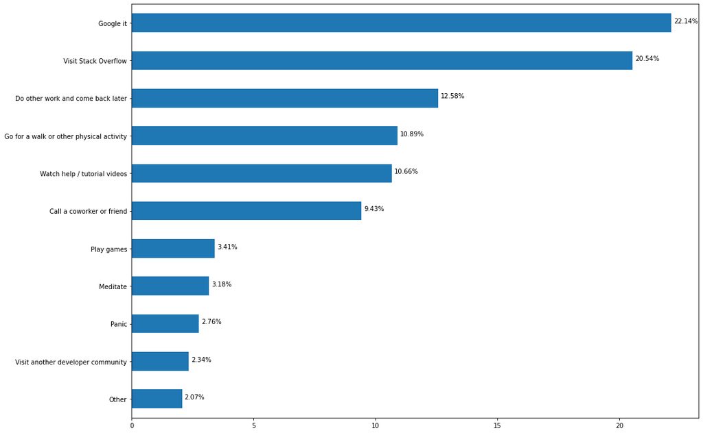

```python
tmp=(
    ds
    .NEWStuck
    .str.split(';', expand=True).stack().reset_index(drop=True)
    .str.split(' \(').str[0]
    .value_counts()
    .pipe(lambda x:x/sum(x)*100)
    .sort_values(ascending=False)
    .to_frame()
    .rename(columns={0:'Perc'})
    .assign(CumPerc = lambda df:df.Perc.cumsum())
)
display(tmp)

fig, ax = plt.subplots(figsize=(16,12))
y =tmp['Perc'].sort_values(ascending=True)
y.plot.barh(ax=ax,)
for i, v in enumerate(y):
    ax.text(v+0.1, i, str(f'{v:.2f}%'), color='black', fontweight='light')
plt.show()
```

- Not far from one another Google it followed by Visit StackOverflow were at the top of the list with an overall perccentage of 43%. One of the bottom options was Visit another developer community, which means SO is one popular reference for developers.

### 9. How active in SO sites vs. other websites

#### NEW SO Sites

|  | Perc | CumPerc |
| --- | --- | --- |
| Stack Overflow | 53.17 | 53.17 |
| Stack Exchange | 43.08 | 96.25 |
| Stack Overflow for Teams | 3.46 | 99.71 |
| None | 0.29 | 100.00 |

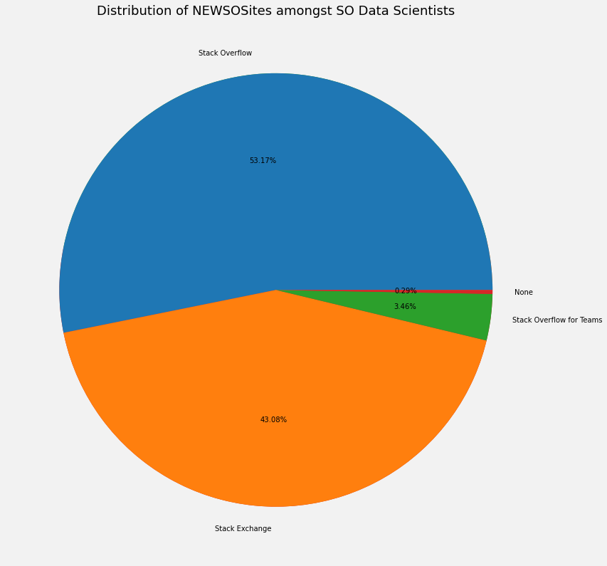

```python
tmp=(
    ds
    .NEWSOSites
    .str.split(';', expand=True).stack().reset_index(drop=True)
    .str.split(' \(').str[0]
    .replace({r'.*never.*':'None'},  regex=True)
    .value_counts(normalize=True)
    .to_frame()
    .mul(100)
    .rename(columns={0:'Perc'})
    .assign(CumPerc = lambda df:df.Perc.cumsum())
)
display(tmp)

fig, ax = plt.subplots(figsize=(14,14))
y =tmp['Perc'].sort_values(ascending=True)
y.plot.pie(ax=ax,labels=None)
ax.get_xaxis().set_visible(False)
frac = tmp.Perc
labels = tmp.index
ax.pie(x=frac, labels=labels, autopct='%1.2f%%')
ax.get_yaxis().set_visible(False)
ax.set_title('Distribution of NEWSOSites amongst SO Data Scientists', fontsize=18)
fig.set_facecolor('grey')
fig.patch.set_alpha(0.1)
plt.show()
```

- Over 53% said they did visit SO site follow by SE with a cumulative perccentage of 96.25. Interestingly, only less than 3.46 have visited SO for Teams.

#### SO Visit Freq

|  | Perc | CumPerc |
| --- | --- | --- |
| Daily or almost daily | 32.20 | 32.20 |
| Multiple times per day | 29.13 | 61.34 |
| A few times per week | 24.46 | 85.80 |
| A few times per month or weekly | 11.98 | 97.78 |
| Less than once per month or monthly | 2.22 | 100.00 |

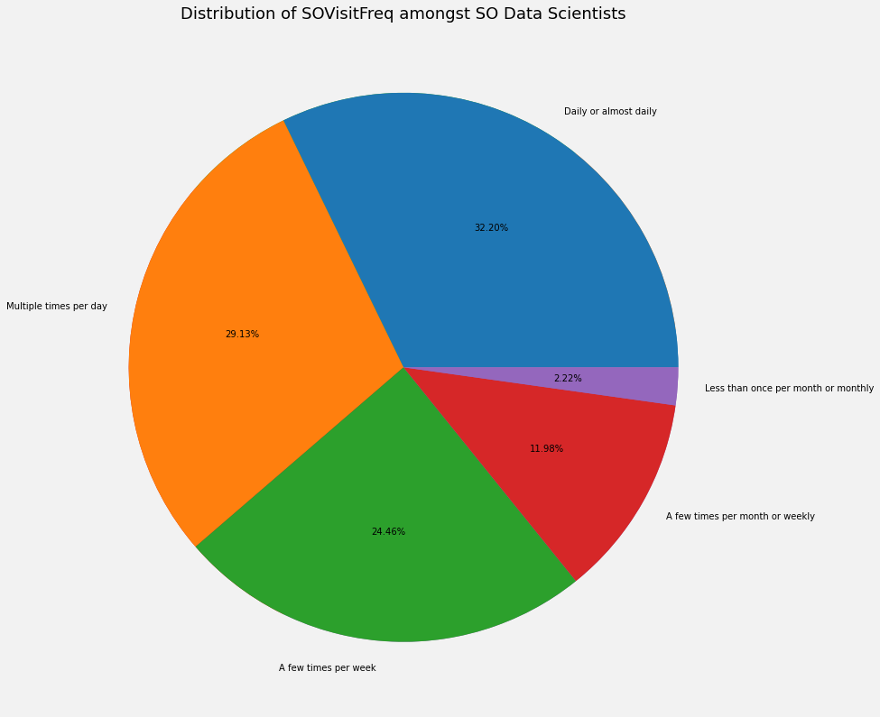

```python
tmp=(
    ds
    .SOVisitFreq
    .value_counts(normalize=True)
    .to_frame()
    .mul(100)
    .rename(columns={'SOVisitFreq':'Perc'})
    .assign(CumPerc = lambda df:df.Perc.cumsum())
)
display(tmp)

fig, ax = plt.subplots(figsize=(14,14))
y =tmp['Perc'].sort_values(ascending=True)
y.plot.pie(ax=ax,labels=None)
ax.get_xaxis().set_visible(False)
frac = tmp.Perc
labels = tmp.index
ax.pie(x=frac, labels=labels, autopct='%1.2f%%')
ax.get_yaxis().set_visible(False)
ax.set_title('Distribution of SOVisitFreq amongst SO Data Scientists', fontsize=18)
fig.set_facecolor('grey')
fig.patch.set_alpha(0.1)
plt.show()
```

- 61.34% of the surveyed DS are visiting SO at least on daily basis followed by a few times a week.

#### SO Account

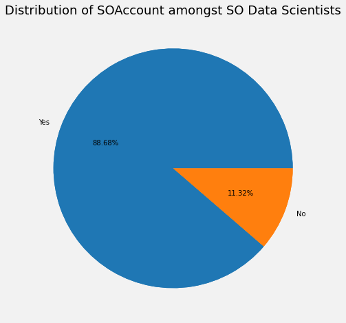

```
Yes   0.89
No    0.11
Name: SOAccount, dtype: float64
```

```python
fig, ax = plt.subplots(figsize=(8,8))
tmp=(
    ds
    .SOAccount
    .replace({r'Not.*':np.nan},  regex=True)
    .dropna()
    .value_counts(normalize=True)
    .to_frame()
)

y =tmp
y =tmp['SOAccount']
y.plot.pie(ax=ax,labels=None)
ax.get_xaxis().set_visible(False)
frac = tmp.SOAccount
labels = tmp.index
ax.pie(x=frac, labels=labels, autopct='%1.2f%%')
ax.get_yaxis().set_visible(False)
ax.set_title('Distribution of SOAccount amongst SO Data Scientists', fontsize=18)
fig.set_facecolor('grey')
fig.patch.set_alpha(0.1)
plt.show()
y
```

- 88.7% of the participant DS do have a SO account.

#### SO Participation Freq

```python
tmp=(
    ds
    .SOPartFreq
    .unique()
)
tmp
```

```
array(['Daily or almost daily', 'A few times per week',
       'Less than once per month or monthly', 'Multiple times per day',
       'A few times per month or weekly',
       'I have never participated in Q&A on Stack Overflow', nan],
      dtype=object)
```

|  | Perc | CumPerc |
| --- | --- | --- |
| Less than once per month or monthly | 41.54 | 41.54 |
| A few times per month or weekly | 22.79 | 64.33 |
| I have never participated in Q&A on Stack Overflow | 16.45 | 80.77 |
| A few times per week | 11.14 | 91.92 |
| Daily or almost daily | 5.19 | 97.11 |
| Multiple times per day | 2.89 | 100.00 |

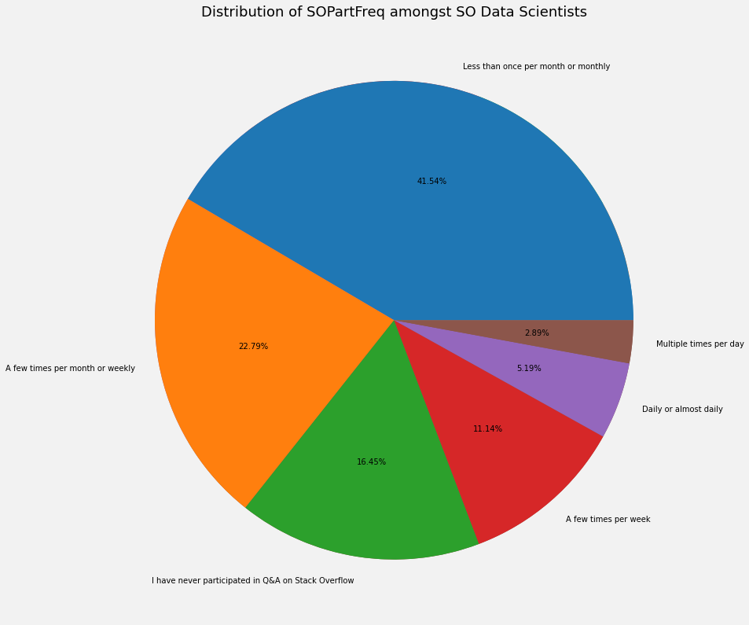

```python
tmp=(
    ds
    .SOPartFreq
    .value_counts(normalize=True)
    .to_frame()
    .mul(100)
    .rename(columns={'SOPartFreq':'Perc'})
    .assign(CumPerc = lambda df:df.Perc.cumsum())
)
display(tmp)

fig, ax = plt.subplots(figsize=(14,14))
y =tmp['Perc'].sort_values(ascending=True)
y.plot.pie(ax=ax,labels=None)
ax.get_xaxis().set_visible(False)
frac = tmp.Perc
labels = tmp.index
ax.pie(x=frac, labels=labels, autopct='%1.2f%%')
ax.get_yaxis().set_visible(False)
ax.set_title('Distribution of SOPartFreq amongst SO Data Scientists', fontsize=18)
fig.set_facecolor('grey')
fig.patch.set_alpha(0.1)
plt.show()
```

```python
tmp=(
    ds
    [['ResponseId','SOPartFreq','SOVisitFreq']]
    .groupby(by=['SOVisitFreq', 'SOPartFreq',], as_index=False)
    .count()
    .sort_values(by='ResponseId', ascending=False)
    .pipe(lambda  df:df[df['SOPartFreq']=='Multiple times per day'])
)
tmp
```

|  | SOVisitFreq | SOPartFreq | ResponseId |
| --- | --- | --- | --- |
| 25 | Multiple times per day | Multiple times per day | 94 |
| 16 | Daily or almost daily | Multiple times per day | 7 |
| 10 | A few times per week | Multiple times per day | 2 |

- I noticed inconsistency in the results as daily participation shall mean daily site visit.

### 10. Stats: Age, Gender, Trans, Sexuality Ethnicity, Accessibility, MentalHealth

#### Age

|  | Perc | CumPerc |
| --- | --- | --- |
| 25-34 years old | 48.98 | 48.98 |
| 35-44 years old | 22.68 | 71.67 |
| 18-24 years old | 16.64 | 88.30 |
| 45-54 years old | 7.73 | 96.03 |
| 55-64 years old | 2.20 | 98.23 |
| Under 18 years old | 0.85 | 99.08 |
| 65 years or older | 0.47 | 99.55 |
| Prefer not to say | 0.45 | 100.00 |

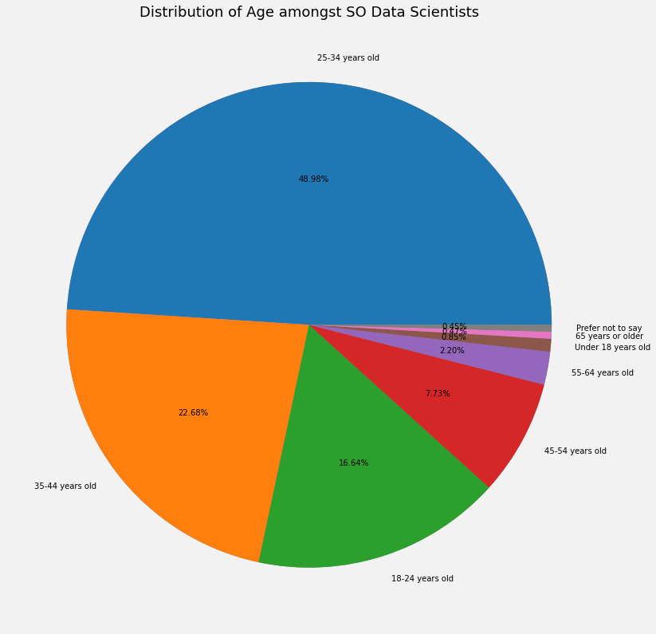

```python
tmp=(
    ds
    .Age
    .value_counts(normalize=True)
    .mul(100)
    .to_frame()
    .rename(columns={'Age':'Perc'})
    .assign(CumPerc = lambda df:df.Perc.cumsum())
)
display(tmp)

fig, ax = plt.subplots(figsize=(14,14))
y =tmp['Perc'].sort_values(ascending=True)
y.plot.pie(ax=ax,labels=None)
ax.get_xaxis().set_visible(False)
frac = tmp.Perc
labels = tmp.index
ax.pie(x=frac, labels=labels, autopct='%1.2f%%')
ax.get_yaxis().set_visible(False)
ax.set_title('Distribution of Age amongst SO Data Scientists', fontsize=18)
fig.set_facecolor('grey')
fig.patch.set_alpha(0.1)
plt.show()
```

- 71.67% of the participating DS said they are aged 25-44 years old, with 17.5 aged 24 or less.

#### Gender

```python
(
    ds
    .Gender
    .unique()
)
```

```
array(['Man', 'Prefer not to say', 'Man;Or, in your own words:', 'Woman',
       'Man;Non-binary, genderqueer, or gender non-conforming', nan,
       'Or, in your own words:',
       'Non-binary, genderqueer, or gender non-conforming',
       'Man;Woman;Non-binary, genderqueer, or gender non-conforming',
       'Man;Woman',
       'Woman;Non-binary, genderqueer, or gender non-conforming',
       'Man;Woman;Non-binary, genderqueer, or gender non-conforming;Or, in your own words:',
       'Woman;Or, in your own words:'], dtype=object)
```

- I noticed inconsistency in this feature so I prefer to ignore it.

#### Transgender

```python
tmp=(
    ds.Trans
    .value_counts(normalize=True)
    .mul(100)
)
tmp
```

```
No                       95.73
Prefer not to say         2.26
Yes                       1.30
Or, in your own words:    0.72
Name: Trans, dtype: float64
```

- I would ignore this feature as i see it biased with over 95% did not identify themselves as transgender.

#### Sexuality

```python
(
    ds
    .Sexuality
    .str.split(';', expand=True).stack().reset_index(drop=True)
    .unique().tolist()
)
```

```
['Straight / Heterosexual',
 'Prefer not to say',
 'Prefer to self-describe:',
 'Gay or Lesbian',
 'Bisexual',
 'Queer']
```

```python
(
    ds
    [['Sexuality']]
    .replace('Prefer to self-describe:',np.nan)
    .assign(Straight_Heterosexual=ds.Sexuality.str.contains('Straight',na=False, regex=True))
    .assign(Gay_Lesbian=ds.Sexuality.str.contains('Gay',na=False, regex=True))
    .assign(Bisexual=ds.Sexuality.str.contains('Bisexual',na=False, regex=True))
    .assign(Queer=ds.Sexuality.str.contains('Queer',na=False, regex=True))
    .assign(None_=ds.Sexuality.str.contains('Prefer',na=False, regex=True))
    .drop(columns=['None_'])
    .assign(Sum = lambda df:df.iloc[:,1:].sum(axis=1))
    .assign(Sexuality = ds.Sexuality)
    .pipe(lambda df:df[df.Sum > 1])
)
```

|  | Sexuality | Straight_Heterosexual | Gay_Lesbian | Bisexual | Queer | Sum |
| --- | --- | --- | --- | --- | --- | --- |
| 310 | Gay or Lesbian;Queer | False | True | False | True | 2 |
| 321 | Straight / Heterosexual;Bisexual;Prefer to sel... | True | True | True | True | 4 |
| 331 | Straight / Heterosexual;Bisexual | True | False | True | False | 2 |
| 343 | Straight / Heterosexual;Bisexual | True | False | True | False | 2 |
| 366 | Straight / Heterosexual;Bisexual | True | False | True | False | 2 |
| ... | ... | ... | ... | ... | ... | ... |
| 3813 | Straight / Heterosexual;Bisexual | True | False | True | False | 2 |
| 3916 | Bisexual;Queer | False | False | True | True | 2 |
| 4054 | Bisexual;Queer | False | False | True | True | 2 |
| 4089 | Bisexual;Gay or Lesbian | False | True | True | False | 2 |
| 4172 | Straight / Heterosexual;Bisexual | True | False | True | False | 2 |

76 rows × 6 columns

- I noticed a few rows with multiple answers like Staright and Gay which is incorrect.

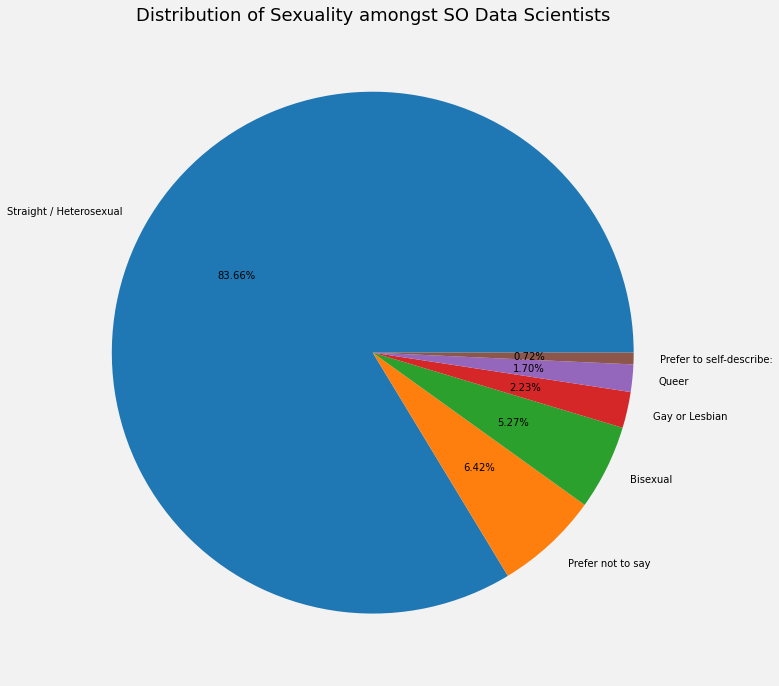

```python
fig, ax = plt.subplots(figsize=(12,12))
(
    ds
    ['Sexuality']
    .replace('Prefer to self-describe:',np.nan)
    .str.split(';', expand=True).stack().reset_index(drop=True)
    .value_counts(normalize=True)
    .mul(100)
    .plot.pie(ax=ax, autopct='%1.2f%%')
)

ax.get_yaxis().set_visible(False)
ax.set_title('Distribution of Sexuality amongst SO Data Scientists', fontsize=18)
fig.set_facecolor('grey')
fig.patch.set_alpha(0.1)
plt.show()
```

- Here I noticed that the majority (over 83%) of the respondents are Straight so I will disregard this feature.

#### Ethnicity

```python
(
    ds
    .Ethnicity
    .str.split(';', expand=True).stack().reset_index(drop=True)
    .unique()
    .tolist()
)
```

```
['White or of European descent',
 'Prefer not to say',
 'South Asian',
 'Hispanic or Latino/a/x',
 'East Asian',
 'Southeast Asian',
 'Multiracial',
 'Biracial',
 'Middle Eastern',
 "I don't know",
 'Or, in your own words:',
 'Indigenous (such as Native American, Pacific Islander, or Indigenous Australian)',
 'Black or of African descent']
```

|  | Perc | CumPerc |
| --- | --- | --- |
| Biracial | 1.71 | 1.71 |
| Multiracial | 1.93 | 3.64 |
| Black or of African descent | 2.56 | 6.20 |
| East Asian | 4.63 | 10.84 |
| Southeast Asian | 4.73 | 15.57 |
| Middle Eastern | 6.08 | 21.65 |
| Hispanic or Latino/a/x | 6.66 | 28.31 |
| South Asian | 12.07 | 40.38 |
| White or of European descent | 59.62 | 100.00 |

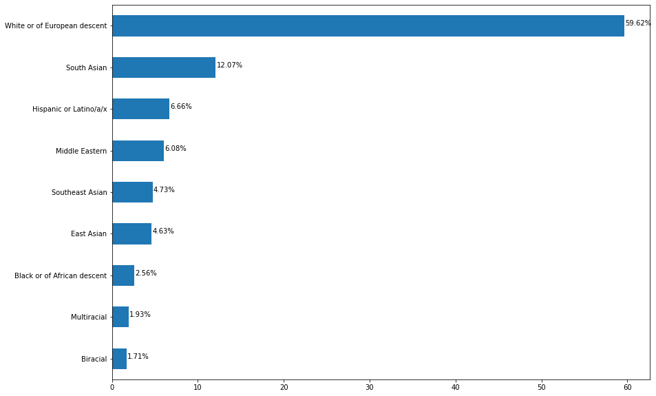

```python
tmp=(
    ds
    .Ethnicity
    .str.split(';', expand=True).stack().reset_index(drop=True)
    .replace(dict.fromkeys(['Or, in your own words:','Prefer not to say', 'I don\'t know'],np.nan))
    .replace({'Indigenous.*':np.nan}, regex=True)
    .value_counts(normalize=True, ascending=True)
    .mul(100)
    .to_frame()
    .rename(columns={0:'Perc'})
    .assign(CumPerc = lambda df: df.Perc.cumsum())
)

display(tmp)
fig, ax = plt.subplots(figsize=(14,10))
y =tmp['Perc'].sort_values(ascending=True)
y.plot.barh(ax=ax,)
for i, v in enumerate(y):
    ax.text(v+0.1, i, str(f'{v:.2f}%'), color='black', fontweight='light')
plt.show()
```

#### Accessibility

|  | Perc | CumPerc |
| --- | --- | --- |
| I am unable to / find it difficult to type | 0.71 | 0.71 |
| I am unable to / find it difficult to walk or stand without assistance | 0.88 | 1.59 |
| I am deaf / hard of hearing | 1.10 | 2.69 |
| Or, in your own words: | 1.18 | 3.87 |
| I am blind / have difficulty seeing | 1.27 | 5.14 |
| Prefer not to say | 3.13 | 8.28 |
| None of the above | 91.72 | 100.00 |

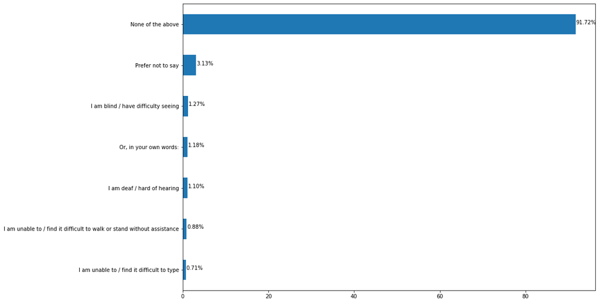

```python
tmp=(
    ds
    .Accessibility
    .str.split(';', expand=True).stack().reset_index(drop=True)
    .value_counts(normalize=True, ascending=True)
    .mul(100)
    .to_frame()
    .rename(columns={0:'Perc'})
    .assign(CumPerc = lambda df: df.Perc.cumsum())
)

display(tmp)
fig, ax = plt.subplots(figsize=(14,10))
y =tmp['Perc'].sort_values(ascending=True)
y.plot.barh(ax=ax,)
for i, v in enumerate(y):
    ax.text(v+0.1, i, str(f'{v:.2f}%'), color='black', fontweight='light')
plt.show()
```

- I noticed here a bias where almost 92% of the respondents who specified their status identified no accessibility issues. So I decided to ignore this feature.

#### Mental Health

|  | Perc | CumPerc |
| --- | --- | --- |
| I have autism / an autism spectrum disorder (e.g. Asperger's) | 3.66 | 3.66 |
| I have a concentration and/or memory disorder (e.g. ADHD) | 8.12 | 11.78 |
| I have an anxiety disorder | 9.05 | 20.83 |
| I have a mood or emotional disorder (e.g. depression, bipolar disorder) | 9.32 | 30.15 |
| None of the above | 69.85 | 100.00 |

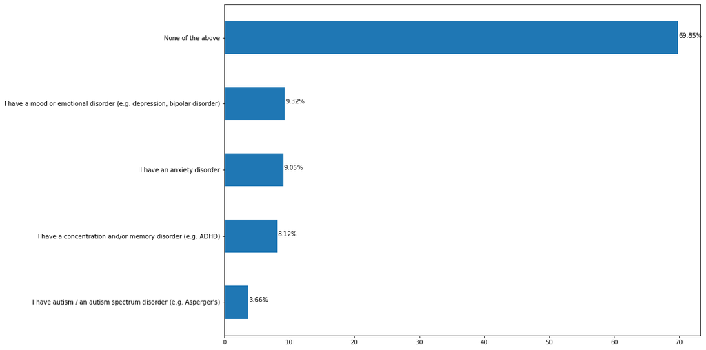

```python
tmp=(
    ds
    .MentalHealth
    .str.split(';', expand=True).stack().reset_index(drop=True)
    .replace(dict.fromkeys(['Or, in your own words:','Prefer not to say'],np.nan))
    .value_counts(normalize=True, ascending=True)
    .mul(100)
    .to_frame()
    .rename(columns={0:'Perc'})
    .assign(CumPerc = lambda df: df.Perc.cumsum())
)

display(tmp)
fig, ax = plt.subplots(figsize=(14,10))
y =tmp['Perc'].sort_values(ascending=True)
y.plot.barh(ax=ax,)
for i, v in enumerate(y):
    ax.text(v+0.1, i, str(f'{v:.2f}%'), color='black', fontweight='light')
plt.show()
```

- I noticed here a bias where almost 70% of the respondents who specified themselves as healthy. So I decided to ignore this feature.

# APPENDIX: Additional Data Exploratory Analysis

## Basic Information

### MainBranch

```python
# Which of the following options best describes you today?
df.stb.freq(['MainBranch'])
```

|  | MainBranch | count | percent | cumulative_count | cumulative_percent |
| --- | --- | --- | --- | --- | --- |
| 0 | I am a developer by profession | 58153 | 69.70 | 58153 | 69.70 |
| 1 | I am a student who is learning to code | 12029 | 14.42 | 70182 | 84.11 |
| 2 | I am not primarily a developer, but I write co... | 6578 | 7.88 | 76760 | 92.00 |
| 3 | I code primarily as a hobby | 4929 | 5.91 | 81689 | 97.90 |
| 4 | I used to be a developer by profession, but no... | 1237 | 1.48 | 82926 | 99.39 |
| 5 | None of these | 513 | 0.61 | 83439 | 100.00 |

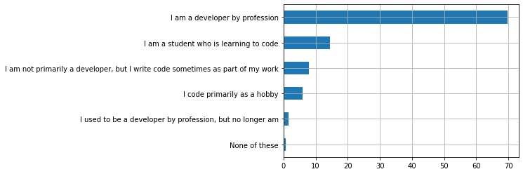

```python
(
    df
    ['MainBranch']
    .value_counts(normalize=True, ascending=True)
    .mul(100)
    .plot.barh(grid=True)

);
```

`Almost 70% of the respondents identify as professional developers.`

### Employment

```python
# Which of the following best describes your current employment status?
df.stb.freq(['Employment'])
```

|  | Employment | count | percent | cumulative_count | cumulative_percent |
| --- | --- | --- | --- | --- | --- |
| 0 | Employed full-time | 53584 | 64.31 | 53584 | 64.31 |
| 1 | Student, full-time | 11781 | 14.14 | 65365 | 78.45 |
| 2 | Independent contractor, freelancer, or self-em... | 8041 | 9.65 | 73406 | 88.10 |
| 3 | Not employed, but looking for work | 2961 | 3.55 | 76367 | 91.65 |
| 4 | Employed part-time | 2461 | 2.95 | 78828 | 94.61 |
| 5 | Student, part-time | 2051 | 2.46 | 80879 | 97.07 |
| 6 | Not employed, and not looking for work | 1228 | 1.47 | 82107 | 98.54 |
| 7 | I prefer not to say | 890 | 1.07 | 82997 | 99.61 |
| 8 | Retired | 326 | 0.39 | 83323 | 100.00 |

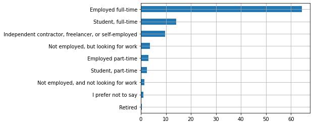

```python
(
    df
    ['Employment']
    .value_counts(normalize=True, ascending=True)
    .mul(100)
    .plot.barh(grid=True)

);
```

`About 65% of the respondents are full-time employed.`

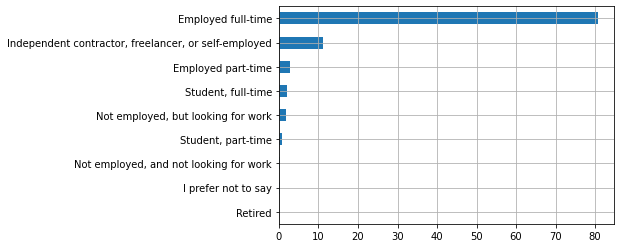

```python
(
    df
    [df['MainBranch']=='I am a developer by profession']
    ['Employment']
    .value_counts(normalize=True, ascending=True)
    .mul(100)
    .plot.barh(grid=True)

);
```

`81% of the professional developers are full-time employed.`

### Country

```python
#Where do you live?
df.stb.freq(['Country'])[:10]
```

|  | Country | count | percent | cumulative_count | cumulative_percent |
| --- | --- | --- | --- | --- | --- |
| 0 | United States of America | 15288 | 18.32 | 15288 | 18.32 |
| 1 | India | 10511 | 12.60 | 25799 | 30.92 |
| 2 | Germany | 5625 | 6.74 | 31424 | 37.66 |
| 3 | United Kingdom of Great Britain and Northern I... | 4475 | 5.36 | 35899 | 43.02 |
| 4 | Canada | 3012 | 3.61 | 38911 | 46.63 |
| 5 | France | 2708 | 3.25 | 41619 | 49.88 |
| 6 | Brazil | 2254 | 2.70 | 43873 | 52.58 |
| 7 | Poland | 1805 | 2.16 | 45678 | 54.74 |
| 8 | Netherlands | 1772 | 2.12 | 47450 | 56.87 |
| 9 | Italy | 1666 | 2.00 | 49116 | 58.86 |

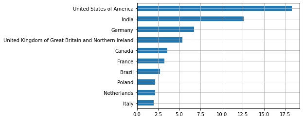

```python
(
    df
    ['Country']
    .value_counts(normalize=True, ascending=True)
    [-10:]
    .mul(100)
    .plot.barh(grid=True)

);
```

`Above table shows that United States of America and India provided the highest volume of survey responses, followed by Germany and UKI (UK and Ireland).`

```python
df.stb.freq(['Country']).Country.nunique()
```

```
181
```

`stackoverflow serves international community from 181 countries.`

```python
# In which state or territory of the USA do you live?
df.stb.freq(['US_State'])[:10]
```

|  | US_State | count | percent | cumulative_count | cumulative_percent |
| --- | --- | --- | --- | --- | --- |
| 0 | California | 2163 | 14.50 | 2163 | 14.50 |
| 1 | Texas | 1023 | 6.86 | 3186 | 21.35 |
| 2 | New York | 961 | 6.44 | 4147 | 27.79 |
| 3 | Washington | 932 | 6.25 | 5079 | 34.04 |
| 4 | Massachusetts | 624 | 4.18 | 5703 | 38.22 |
| 5 | Florida | 613 | 4.11 | 6316 | 42.33 |
| 6 | Illinois | 587 | 3.93 | 6903 | 46.27 |
| 7 | Colorado | 549 | 3.68 | 7452 | 49.95 |
| 8 | Pennsylvania | 499 | 3.34 | 7951 | 53.29 |
| 9 | Virginia | 453 | 3.04 | 8404 | 56.33 |

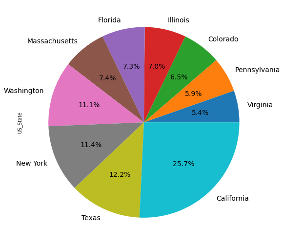

```python
fig, ax = plt.subplots(figsize=(16,9))
(
    df
    ['US_State']
    .value_counts(normalize=True, ascending=True)
    [-10:]
    .mul(100)
    .plot.pie(ax=ax, autopct='%1.1f%%', startangle=0, fontsize=14)

);
```

```python
# In which part of the United Kingdom do you live?
df.stb.freq(['UK_Country'])
```

|  | UK_Country | count | percent | cumulative_count | cumulative_percent |
| --- | --- | --- | --- | --- | --- |
| 0 | England | 3915 | 88.61 | 3915 | 88.61 |
| 1 | Scotland | 341 | 7.72 | 4256 | 96.33 |
| 2 | Wales | 86 | 1.95 | 4342 | 98.28 |
| 3 | Northern Ireland | 76 | 1.72 | 4418 | 100.00 |

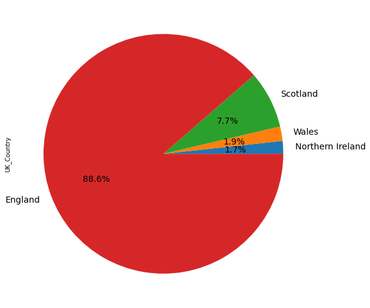

```python
fig, ax = plt.subplots(figsize=(16,9))
(
    df
    ['UK_Country']
    .value_counts(normalize=True, ascending=True)
    .mul(100)
    .plot.pie(ax=ax, autopct='%1.1f%%', startangle=0, fontsize=14)

);
```

`89% of UKI respondents came from England.`

## Education + Work + Career

### Education Level

```python
# Which of the following best describes the highest level of formal education that you’ve completed? *
df.stb.freq(['EdLevel'])
```

|  | EdLevel | count | percent | cumulative_count | cumulative_percent |
| --- | --- | --- | --- | --- | --- |
| 0 | Bachelor’s degree (B.A., B.S., B.Eng., etc.) | 35357 | 42.53 | 35357 | 42.53 |
| 1 | Master’s degree (M.A., M.S., M.Eng., MBA, etc.) | 17512 | 21.07 | 52869 | 63.60 |
| 2 | Some college/university study without earning ... | 10589 | 12.74 | 63458 | 76.34 |
| 3 | Secondary school (e.g. American high school, G... | 9534 | 11.47 | 72992 | 87.81 |
| 4 | Other doctoral degree (Ph.D., Ed.D., etc.) | 2567 | 3.09 | 75559 | 90.90 |
| 5 | Primary/elementary school | 2479 | 2.98 | 78038 | 93.88 |
| 6 | Associate degree (A.A., A.S., etc.) | 2231 | 2.68 | 80269 | 96.56 |
| 7 | Something else | 1601 | 1.93 | 81870 | 98.49 |
| 8 | Professional degree (JD, MD, etc.) | 1256 | 1.51 | 83126 | 100.00 |

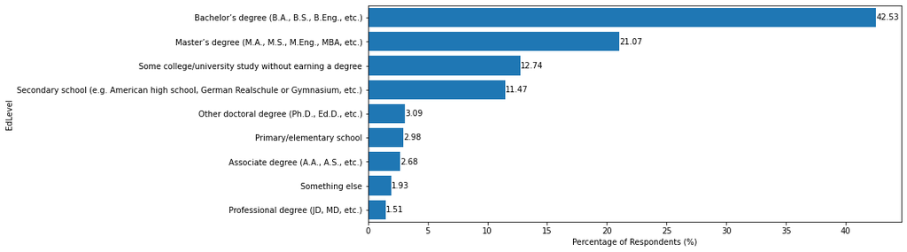

```python
fig, ax = plt.subplots(figsize=(12,8))
plot_df = df.stb.freq(['EdLevel']).iloc[:, [0,2]].set_index(keys='EdLevel')
plot_df.sort_values('percent',inplace=True)
indexes = plot_df.index
values = plot_df['percent'].values.round(2)

plot_df.plot.barh(ax=ax, legend=False)

bars = ax.barh(indexes, values)
ax.bar_label(bars)
ax.set_xlabel('Percentage of Respondents (%)')
plt.show()
```

`42.53% of the respondents graduated with BSc degree followed by MSc and least coming with Professional degree (JD, MD, etc.).`

### Age 1st Code

```python
# At what age did you write your first line of code or program? (e.g., webpage, Hello World, Scratch project)
df.stb.freq(['Age1stCode'])
```

|  | Age1stCode | count | percent | cumulative_count | cumulative_percent |
| --- | --- | --- | --- | --- | --- |
| 0 | 11 - 17 years | 44170 | 53.06 | 44170 | 53.06 |
| 1 | 18 - 24 years | 20065 | 24.10 | 64235 | 77.17 |
| 2 | 5 - 10 years | 11720 | 14.08 | 75955 | 91.24 |
| 3 | 25 - 34 years | 4199 | 5.04 | 80154 | 96.29 |
| 4 | 35 - 44 years | 1312 | 1.58 | 81466 | 97.87 |
| 5 | Younger than 5 years | 905 | 1.09 | 82371 | 98.95 |
| 6 | 45 - 54 years | 544 | 0.65 | 82915 | 99.61 |
| 7 | 55 - 64 years | 245 | 0.29 | 83160 | 99.90 |
| 8 | Older than 64 years | 83 | 0.10 | 83243 | 100.00 |

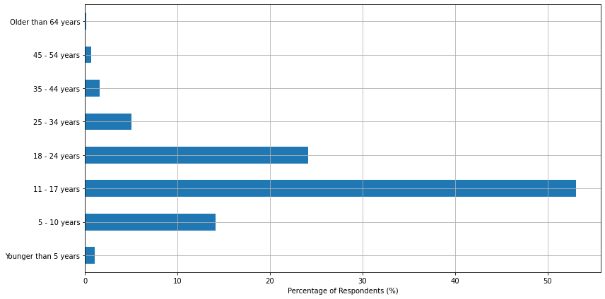

```python
fig, ax = plt.subplots(figsize=(12,6))
(
    df
    ['Age1stCode']
    .value_counts(normalize=True, ascending=True)
    .mul(100)
    .reindex(['Younger than 5 years', '5 - 10 years','11 - 17 years',
    '18 - 24 years', '25 - 34 years', '35 - 44 years', '45 - 54 years', 'Older than 64 years'])
    .plot.barh(grid=True, ax=ax)

)
ax.set_xlabel('Percentage of Respondents (%)')
fig.tight_layout()
```

`Coders start young: over 50% of respondents wrote their first line of code between the ages of 11 to 17.`

### Learn Code

```python
# How did you learn to code?
data = df['LearnCode'].copy()
data = data.str.split(';', expand=True).stack().reset_index(drop=True)
pd.DataFrame(data, columns=['LearnCode']).stb.freq(['LearnCode'])
```

|  | LearnCode | count | percent | cumulative_count | cumulative_percent |
| --- | --- | --- | --- | --- | --- |
| 0 | Other online resources (ex: videos, blogs, etc) | 49392 | 20.48 | 49392 | 20.48 |
| 1 | School | 44462 | 18.44 | 93854 | 38.92 |
| 2 | Books / Physical media | 42752 | 17.73 | 136606 | 56.65 |
| 3 | Online Courses or Certification | 33511 | 13.90 | 170117 | 70.54 |
| 4 | Online Forum | 26229 | 10.88 | 196346 | 81.42 |
| 5 | Friend or family member | 15162 | 6.29 | 211508 | 87.71 |
| 6 | Colleague | 14225 | 5.90 | 225733 | 93.61 |
| 7 | Coding Bootcamp | 8496 | 3.52 | 234229 | 97.13 |
| 8 | Other (please specify): | 6924 | 2.87 | 241153 | 100.00 |

`We notice that the top learning experience was through Other online resources (ex: videos, blogs, etc)`

### Years Code

```python
# Including any education, how many years have you been coding in total?
data = df['YearsCode'].copy()
data[data.str.contains('Less', na=False)] = 0
data[data.str.contains('More', na=False)] = 55
data = data.astype(float)
pd.DataFrame(pd.cut(data, range(0, 56, 5))).stb.freq(['YearsCode']).sort_values(by='YearsCode')
```

|  | YearsCode | count | percent | cumulative_count | cumulative_percent |
| --- | --- | --- | --- | --- | --- |
| 1 | (0, 5] | 20725 | 25.86 | 45020 | 56.17 |
| 0 | (5, 10] | 24295 | 30.31 | 24295 | 30.31 |
| 2 | (10, 15] | 12986 | 16.20 | 58006 | 72.37 |
| 3 | (15, 20] | 8286 | 10.34 | 66292 | 82.71 |
| 4 | (20, 25] | 5238 | 6.54 | 71530 | 89.24 |
| 5 | (25, 30] | 3337 | 4.16 | 74867 | 93.41 |
| 6 | (30, 35] | 2134 | 2.66 | 77001 | 96.07 |
| 7 | (35, 40] | 1989 | 2.48 | 78990 | 98.55 |
| 8 | (40, 45] | 752 | 0.94 | 79742 | 99.49 |
| 9 | (45, 50] | 240 | 0.30 | 79982 | 99.79 |
| 10 | (50, 55] | 170 | 0.21 | 80152 | 100.00 |

`We notice here that more than 55% of the respondents have been coding for ten years or less.`

### Years Code Pro

```python
# NOT including education, how many years have you coded professionally (as a part of your work)?
data = df['YearsCodePro'].copy()
data[data.str.contains('Less', na=False)] = 0
data[data.str.contains('More', na=False)] = 55
data = data.astype(float)
pd.DataFrame(pd.cut(data, range(0, 56, 5))).stb.freq(['YearsCodePro'])
```

|  | YearsCodePro | count | percent | cumulative_count | cumulative_percent |
| --- | --- | --- | --- | --- | --- |
| 0 | (0, 5] | 24229 | 41.41 | 24229 | 41.41 |
| 1 | (5, 10] | 15401 | 26.32 | 39630 | 67.72 |
| 2 | (10, 15] | 7874 | 13.46 | 47504 | 81.18 |
| 3 | (15, 20] | 4662 | 7.97 | 52166 | 89.15 |
| 4 | (20, 25] | 3285 | 5.61 | 55451 | 94.76 |
| 5 | (25, 30] | 1452 | 2.48 | 56903 | 97.24 |
| 6 | (30, 35] | 850 | 1.45 | 57753 | 98.69 |
| 7 | (35, 40] | 478 | 0.82 | 58231 | 99.51 |
| 8 | (40, 45] | 184 | 0.31 | 58415 | 99.83 |
| 9 | (45, 50] | 52 | 0.09 | 58467 | 99.91 |
| 10 | (50, 55] | 50 | 0.09 | 58517 | 100.00 |

`A majority of respondents have been working for ten or less years as a professional developer, meaning they’ve never worked in a world without Stack Overflow.`

### Dev Type

```python
# Which of the following describes your current job?
data = df['DevType'].copy()
data = data.str.split(';', expand=True).stack().reset_index(drop=True)
pd.DataFrame(data, columns=['DevType']).stb.freq(['DevType'])
```

|  | DevType | count | percent | cumulative_count | cumulative_percent |
| --- | --- | --- | --- | --- | --- |
| 0 | Developer, full-stack | 32891 | 18.89 | 32891 | 18.89 |
| 1 | Developer, back-end | 29071 | 16.70 | 61962 | 35.59 |
| 2 | Developer, front-end | 18231 | 10.47 | 80193 | 46.07 |
| 3 | Developer, desktop or enterprise applications | 11036 | 6.34 | 91229 | 52.41 |
| 4 | Developer, mobile | 9800 | 5.63 | 101029 | 58.04 |
| 5 | DevOps specialist | 7058 | 4.05 | 108087 | 62.09 |
| 6 | System administrator | 6079 | 3.49 | 114166 | 65.58 |
| 7 | Database administrator | 5655 | 3.25 | 119821 | 68.83 |
| 8 | Designer | 4611 | 2.65 | 124432 | 71.48 |
| 9 | Developer, embedded applications or devices | 4598 | 2.64 | 129030 | 74.12 |
| 10 | Data scientist or machine learning specialist | 4273 | 2.45 | 133303 | 76.57 |
| 11 | Student | 4187 | 2.41 | 137490 | 78.98 |
| 12 | Engineer, data | 4176 | 2.40 | 141666 | 81.38 |
| 13 | Engineering manager | 3810 | 2.19 | 145476 | 83.57 |
| 14 | Data or business analyst | 3792 | 2.18 | 149268 | 85.75 |
| 15 | Developer, QA or test | 3611 | 2.07 | 152879 | 87.82 |
| 16 | Other (please specify): | 3545 | 2.04 | 156424 | 89.86 |
| 17 | Product manager | 3074 | 1.77 | 159498 | 91.62 |
| 18 | Academic researcher | 2899 | 1.67 | 162397 | 93.29 |
| 19 | Engineer, site reliability | 2448 | 1.41 | 164845 | 94.69 |
| 20 | Educator | 2369 | 1.36 | 167214 | 96.05 |
| 21 | Developer, game or graphics | 2112 | 1.21 | 169326 | 97.27 |
| 22 | Senior Executive (C-Suite, VP, etc.) | 2103 | 1.21 | 171429 | 98.48 |
| 23 | Scientist | 2015 | 1.16 | 173444 | 99.63 |
| 24 | Marketing or sales professional | 638 | 0.37 | 174082 | 100.00 |

`People holding full stack developer roles are the most prevalent. Full stack, back-end, front-end, and desktop developers continue to account for the majority of all respondents.`

```python
(
    df
    [['DevType', 'EdLevel']]
    .DevType.str.get_dummies(sep=';')
    .assign(
        EdLevel=df.EdLevel
    )
    .reset_index(drop=True)
    .groupby('EdLevel')
    .sum()
    .T
    .style.highlight_max(color = 'lightgreen')
)
```

| EdLevel | Associate degree (A.A., A.S., etc.) | Bachelor’s degree (B.A., B.S., B.Eng., etc.) | Master’s degree (M.A., M.S., M.Eng., MBA, etc.) | Other doctoral degree (Ph.D., Ed.D., etc.) | Primary/elementary school | Professional degree (JD, MD, etc.) | Secondary school (e.g. American high school, German Realschule or Gymnasium, etc.) | Some college/university study without earning a degree | Something else |
| --- | --- | --- | --- | --- | --- | --- | --- | --- | --- |
| Academic researcher | 29 | 569 | 1075 | 928 | 43 | 71 | 48 | 114 | 20 |
| Data or business analyst | 113 | 1563 | 1108 | 198 | 35 | 96 | 149 | 460 | 62 |
| Data scientist or machine learning specialist | 42 | 1316 | 1740 | 710 | 31 | 71 | 107 | 222 | 31 |
| Database administrator | 232 | 2398 | 1131 | 117 | 80 | 155 | 415 | 1000 | 117 |
| Designer | 200 | 1935 | 893 | 119 | 94 | 121 | 363 | 769 | 107 |
| DevOps specialist | 225 | 3232 | 1810 | 153 | 53 | 109 | 372 | 1013 | 86 |
| Developer, QA or test | 130 | 1719 | 792 | 72 | 35 | 76 | 188 | 527 | 67 |
| Developer, back-end | 843 | 14278 | 6959 | 652 | 230 | 500 | 1531 | 3671 | 367 |
| Developer, desktop or enterprise applications | 349 | 4919 | 2788 | 295 | 103 | 276 | 649 | 1469 | 171 |
| Developer, embedded applications or devices | 111 | 1955 | 1349 | 157 | 47 | 102 | 264 | 533 | 74 |
| Developer, front-end | 651 | 8965 | 3592 | 236 | 187 | 381 | 1203 | 2682 | 310 |
| Developer, full-stack | 1037 | 16375 | 7308 | 558 | 267 | 603 | 1863 | 4366 | 478 |
| Developer, game or graphics | 82 | 812 | 450 | 62 | 67 | 51 | 208 | 330 | 45 |
| Developer, mobile | 301 | 4827 | 2065 | 122 | 98 | 235 | 585 | 1402 | 151 |
| Educator | 51 | 755 | 705 | 363 | 25 | 63 | 104 | 257 | 42 |
| Engineer, data | 92 | 1799 | 1352 | 264 | 36 | 76 | 136 | 379 | 40 |
| Engineer, site reliability | 81 | 1145 | 541 | 54 | 19 | 46 | 138 | 388 | 33 |
| Engineering manager | 82 | 1633 | 1184 | 166 | 29 | 82 | 139 | 452 | 41 |
| Marketing or sales professional | 21 | 235 | 146 | 14 | 13 | 19 | 50 | 122 | 17 |
| Other (please specify): | 115 | 1354 | 917 | 174 | 41 | 78 | 255 | 520 | 86 |
| Product manager | 68 | 1303 | 833 | 111 | 41 | 88 | 157 | 419 | 47 |
| Scientist | 12 | 349 | 706 | 741 | 23 | 58 | 31 | 74 | 19 |
| Senior Executive (C-Suite, VP, etc.) | 37 | 821 | 580 | 121 | 26 | 55 | 119 | 314 | 27 |
| Student | 144 | 1569 | 520 | 43 | 142 | 55 | 784 | 834 | 90 |
| System administrator | 242 | 2382 | 1231 | 162 | 102 | 137 | 527 | 1160 | 127 |

`We notice that Developer, full-stack wins the race in every education level except in Ph.D.`

### Org Size

```python
# Approximately how many people are employed by the company or organization you currently work for?
data = df['OrgSize'].copy()
data = data.str.replace(' employees','')
data[data.str.contains('Just me', na=False)] = '1'
# data = data.str.split(';', expand=True).stack().reset_index(drop=True)
pd.DataFrame(data, columns=['OrgSize']).stb.freq(['OrgSize'])
```

|  | OrgSize | count | percent | cumulative_count | cumulative_percent |
| --- | --- | --- | --- | --- | --- |
| 0 | 20 to 99 | 12507 | 20.60 | 12507 | 20.60 |
| 1 | 100 to 499 | 10506 | 17.30 | 23013 | 37.90 |
| 2 | 10,000 or more | 8016 | 13.20 | 31029 | 51.10 |
| 3 | 2 to 9 | 6551 | 10.79 | 37580 | 61.88 |
| 4 | 1,000 to 4,999 | 6287 | 10.35 | 43867 | 72.24 |
| 5 | 10 to 19 | 5404 | 8.90 | 49271 | 81.14 |
| 6 | 1 | 4033 | 6.64 | 53304 | 87.78 |
| 7 | 500 to 999 | 3789 | 6.24 | 57093 | 94.02 |
| 8 | 5,000 to 9,999 | 2279 | 3.75 | 59372 | 97.77 |
| 9 | I don’t know | 1354 | 2.23 | 60726 | 100.00 |

### Currency

```python
# Which currency do you use day-to-day
data = df['Currency'].copy()
data = data.str.replace('\t', ' ')
pd.DataFrame(data, columns=['Currency']).stb.freq(['Currency'])[:10] # top 10
```

|  | Currency | count | percent | cumulative_count | cumulative_percent |
| --- | --- | --- | --- | --- | --- |
| 0 | USD United States dollar | 14363 | 23.52 | 14363 | 23.52 |
| 1 | EUR European Euro | 13932 | 22.81 | 28295 | 46.32 |
| 2 | INR Indian rupee | 6427 | 10.52 | 34722 | 56.85 |
| 3 | GBP Pound sterling | 3547 | 5.81 | 38269 | 62.65 |
| 4 | CAD Canadian dollar | 2108 | 3.45 | 40377 | 66.11 |
| 5 | BRL Brazilian real | 1755 | 2.87 | 42132 | 68.98 |
| 6 | AUD Australian dollar | 1272 | 2.08 | 43404 | 71.06 |
| 7 | PLN Polish zloty | 1268 | 2.08 | 44672 | 73.14 |
| 8 | RUB Russian ruble | 1062 | 1.74 | 45734 | 74.88 |
| 9 | SEK Swedish krona | 942 | 1.54 | 46676 | 76.42 |

```python
# Which currency do you use day-to-day
data = df['Currency'].copy()
data = data.str.replace('\t', ' ')
pd.DataFrame(data, columns=['Currency']).stb.freq(['Currency'])[-10:] # bottom 10
```

|  | Currency | count | percent | cumulative_count | cumulative_percent |
| --- | --- | --- | --- | --- | --- |
| 136 | SRD Surinamese dollar | 1 | 0.00 | 61071 | 99.99 |
| 137 | SHP Saint Helena pound | 1 | 0.00 | 61072 | 99.99 |
| 138 | PGK Papua New Guinean kina | 1 | 0.00 | 61073 | 99.99 |
| 139 | KPW North Korean won | 1 | 0.00 | 61074 | 99.99 |
| 140 | IMP Manx pound | 1 | 0.00 | 61075 | 99.99 |
| 141 | GGP Guernsey Pound | 1 | 0.00 | 61076 | 99.99 |
| 142 | ERN Eritrean nakfa | 1 | 0.00 | 61077 | 100.00 |
| 143 | CVE Cape Verdean escudo | 1 | 0.00 | 61078 | 100.00 |
| 144 | CDF Congolese franc | 1 | 0.00 | 61079 | 100.00 |
| 145 | BMD Bermudian dollar | 1 | 0.00 | 61080 | 100.00 |

### Converted Comp Yearly

```python
# What is your current total compensation (salary, bonuses, and perks, before taxes and deductions)
bins = df['ConvertedCompYearly'].quantile([0, .25, .5, .75, .9, .95, .99, 1]).values.tolist()
data = pd.cut(df['ConvertedCompYearly'], bins)
pd.DataFrame(data, columns=['ConvertedCompYearly']).stb.freq(['ConvertedCompYearly'])
```

|  | ConvertedCompYearly | count | percent | cumulative_count | cumulative_percent |
| --- | --- | --- | --- | --- | --- |
| 0 | (56211.0, 100000.0] | 12027 | 25.68 | 12027 | 25.68 |
| 1 | (1.0, 27025.0] | 11736 | 25.05 | 23763 | 50.73 |
| 2 | (27025.0, 56211.0] | 11717 | 25.01 | 35480 | 75.75 |
| 3 | (100000.0, 160000.0] | 6680 | 14.26 | 42160 | 90.01 |
| 4 | (160000.0, 240000.0] | 2357 | 5.03 | 44517 | 95.04 |
| 5 | (240000.0, 1200000.0] | 1857 | 3.96 | 46374 | 99.00 |
| 6 | (1200000.0, 45241312.0] | 467 | 1.00 | 46841 | 100.00 |

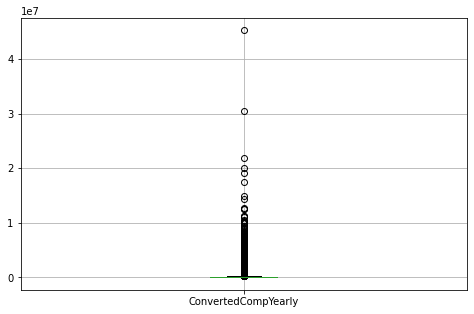

```python
fig, ax = plt.subplots(figsize=(8,5))
plot_df = df[['ConvertedCompYearly']]
plot_df.boxplot(ax=ax);
```

`We notice a huge amount of right skewness due to extremely high values, probably wrong entry.`

```python
desc = df.describe().loc[['25%', '75%'],['ConvertedCompYearly']]
q1 = desc.values[0][0]
q3 = desc.values[1][0]
iqr = q3-q1
upper_bound = q3+(1.5*iqr)
lower_bound = q1-(1.5*iqr)
print(f'iqr: {iqr}\nupper_bound: {upper_bound}\nlower_bound: {lower_bound}')
```

```
iqr: 72975.0
upper_bound: 209462.5
lower_bound: -82437.5
```

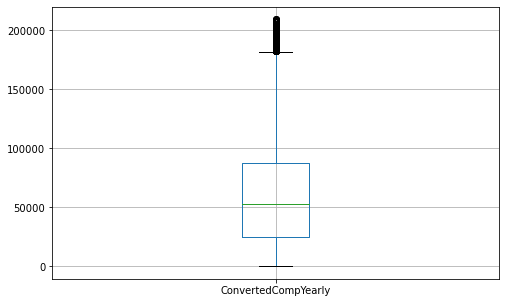

```python
plot_df = df[['ConvertedCompYearly']]
df_boxplot = plot_df[(plot_df.ConvertedCompYearly > lower_bound) & (plot_df.ConvertedCompYearly < upper_bound)]
fig, ax = plt.subplots(figsize=(8,5))
df_boxplot.boxplot(ax=ax)
plt.show()
```

`Above is boxplot after removing the outliers.`

## Technology and Tech Culture

### Languages

```python
# top programming, scripting, and markup languages by popularity
data = df['LanguageHaveWorkedWith'].copy()
data = data.str.split(';', expand=True).stack().reset_index(drop=True)
pd.DataFrame(data, columns=['LanguageHaveWorkedWith']).stb.freq(['LanguageHaveWorkedWith'])
```

|  | LanguageHaveWorkedWith | count | percent | cumulative_count | cumulative_percent |
| --- | --- | --- | --- | --- | --- |
| 0 | JavaScript | 53587 | 12.11 | 53587 | 12.11 |
| 1 | HTML/CSS | 46259 | 10.45 | 99846 | 22.56 |
| 2 | Python | 39792 | 8.99 | 139638 | 31.55 |
| 3 | SQL | 38835 | 8.78 | 178473 | 40.33 |
| 4 | Java | 29162 | 6.59 | 207635 | 46.92 |
| 5 | Node.js | 27975 | 6.32 | 235610 | 53.24 |
| 6 | TypeScript | 24909 | 5.63 | 260519 | 58.87 |
| 7 | C# | 22984 | 5.19 | 283503 | 64.06 |
| 8 | Bash/Shell | 22385 | 5.06 | 305888 | 69.12 |
| 9 | C++ | 20057 | 4.53 | 325945 | 73.65 |
| 10 | PHP | 18130 | 4.10 | 344075 | 77.75 |
| 11 | C | 17329 | 3.92 | 361404 | 81.66 |
| 12 | PowerShell | 8871 | 2.00 | 370275 | 83.67 |
| 13 | Go | 7879 | 1.78 | 378154 | 85.45 |
| 14 | Kotlin | 6866 | 1.55 | 385020 | 87.00 |
| 15 | Rust | 5799 | 1.31 | 390819 | 88.31 |
| 16 | Ruby | 5569 | 1.26 | 396388 | 89.57 |
| 17 | Dart | 4965 | 1.12 | 401353 | 90.69 |
| 18 | Assembly | 4632 | 1.05 | 405985 | 91.74 |
| 19 | Swift | 4204 | 0.95 | 410189 | 92.69 |
| 20 | R | 4185 | 0.95 | 414374 | 93.63 |
| 21 | VBA | 3847 | 0.87 | 418221 | 94.50 |
| 22 | Matlab | 3846 | 0.87 | 422067 | 95.37 |
| 23 | Groovy | 2479 | 0.56 | 424546 | 95.93 |
| 24 | Objective-C | 2310 | 0.52 | 426856 | 96.45 |
| 25 | Scala | 2148 | 0.49 | 429004 | 96.94 |
| 26 | Perl | 2028 | 0.46 | 431032 | 97.40 |
| 27 | Haskell | 1749 | 0.40 | 432781 | 97.79 |
| 28 | Delphi | 1731 | 0.39 | 434512 | 98.18 |
| 29 | Clojure | 1552 | 0.35 | 436064 | 98.53 |
| 30 | Elixir | 1438 | 0.32 | 437502 | 98.86 |
| 31 | LISP | 1096 | 0.25 | 438598 | 99.10 |
| 32 | Julia | 1068 | 0.24 | 439666 | 99.35 |
| 33 | F# | 804 | 0.18 | 440470 | 99.53 |
| 34 | Erlang | 651 | 0.15 | 441121 | 99.67 |
| 35 | APL | 536 | 0.12 | 441657 | 99.80 |
| 36 | Crystal | 466 | 0.11 | 442123 | 99.90 |
| 37 | COBOL | 437 | 0.10 | 442560 | 100.00 |

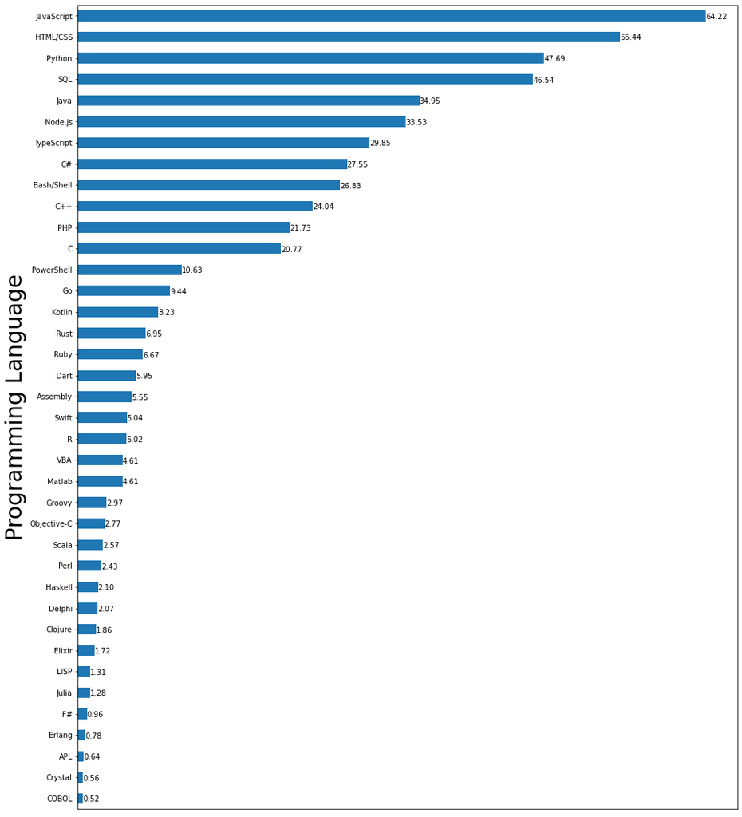

```python
fig, ax = plt.subplots(figsize=(16, 20))
(
    df
    ['LanguageHaveWorkedWith']
    .str.get_dummies(';')
    .pipe(lambda df:df.apply(pd.Series.value_counts))
    .pipe(lambda df:df.div(df.shape[0]))
    .iloc[1,:]
    .sort_values(ascending=True)
    .mul(100)
    .plot.barh(ax=ax)

)

for p in ax.patches:
    w = p.get_width()
    ax.annotate(f'{w:.2f}', (w * 1., p.get_y() + 0.1))
ax.set_ylabel(ylabel='Programming Language', fontsize=30)
ax.set_xticks([])
# fig.savefig('programming_lang.png')
plt.show()
```

```python
# top programming, scripting, and markup languages by interest
data = df['LanguageWantToWorkWith'].copy()
data = data.str.split(';', expand=True).stack().reset_index(drop=True)
pd.DataFrame(data, columns=['LanguageWantToWorkWith']).stb.freq(['LanguageWantToWorkWith'])
```

|  | LanguageWantToWorkWith | count | percent | cumulative_count | cumulative_percent |
| --- | --- | --- | --- | --- | --- |
| 0 | JavaScript | 37008 | 10.17 | 37008 | 10.17 |
| 1 | Python | 34929 | 9.59 | 71937 | 19.76 |
| 2 | HTML/CSS | 29353 | 8.06 | 101290 | 27.82 |
| 3 | TypeScript | 26905 | 7.39 | 128195 | 35.21 |
| 4 | SQL | 26631 | 7.31 | 154826 | 42.53 |
| 5 | Node.js | 24100 | 6.62 | 178926 | 49.15 |
| 6 | C# | 17999 | 4.94 | 196925 | 54.09 |
| 7 | Java | 17222 | 4.73 | 214147 | 58.82 |
| 8 | Rust | 15865 | 4.36 | 230012 | 63.18 |
| 9 | Go | 15788 | 4.34 | 245800 | 67.52 |
| 10 | C++ | 15249 | 4.19 | 261049 | 71.70 |
| 11 | Bash/Shell | 14043 | 3.86 | 275092 | 75.56 |
| 12 | Kotlin | 10691 | 2.94 | 285783 | 78.50 |
| 13 | C | 9702 | 2.66 | 295485 | 81.16 |
| 14 | PHP | 8852 | 2.43 | 304337 | 83.59 |
| 15 | Dart | 7018 | 1.93 | 311355 | 85.52 |
| 16 | Swift | 6353 | 1.75 | 317708 | 87.27 |
| 17 | Ruby | 4942 | 1.36 | 322650 | 88.62 |
| 18 | PowerShell | 4896 | 1.34 | 327546 | 89.97 |
| 19 | R | 4015 | 1.10 | 331561 | 91.07 |
| 20 | Assembly | 3578 | 0.98 | 335139 | 92.06 |
| 21 | Haskell | 3453 | 0.95 | 338592 | 93.00 |
| 22 | Elixir | 3374 | 0.93 | 341966 | 93.93 |
| 23 | Scala | 3165 | 0.87 | 345131 | 94.80 |
| 24 | Julia | 2445 | 0.67 | 347576 | 95.47 |
| 25 | Clojure | 2413 | 0.66 | 349989 | 96.13 |
| 26 | F# | 2157 | 0.59 | 352146 | 96.73 |
| 27 | Matlab | 1562 | 0.43 | 353708 | 97.16 |
| 28 | LISP | 1513 | 0.42 | 355221 | 97.57 |
| 29 | Objective-C | 1400 | 0.38 | 356621 | 97.96 |
| 30 | Erlang | 1379 | 0.38 | 358000 | 98.33 |
| 31 | Groovy | 1177 | 0.32 | 359177 | 98.66 |
| 32 | Perl | 1175 | 0.32 | 360352 | 98.98 |
| 33 | VBA | 1069 | 0.29 | 361421 | 99.27 |
| 34 | Delphi | 975 | 0.27 | 362396 | 99.54 |
| 35 | Crystal | 790 | 0.22 | 363186 | 99.76 |
| 36 | APL | 568 | 0.16 | 363754 | 99.92 |
| 37 | COBOL | 309 | 0.08 | 364063 | 100.00 |

### Database

```python
# top database environments by popularity
data = df['DatabaseHaveWorkedWith'].copy()
data = data.str.split(';', expand=True).stack().reset_index(drop=True)
pd.DataFrame(data, columns=['DatabaseHaveWorkedWith']).stb.freq(['DatabaseHaveWorkedWith'])
```

|  | DatabaseHaveWorkedWith | count | percent | cumulative_count | cumulative_percent |
| --- | --- | --- | --- | --- | --- |
| 0 | MySQL | 35289 | 18.53 | 35289 | 18.53 |
| 1 | PostgreSQL | 28424 | 14.92 | 63713 | 33.45 |
| 2 | SQLite | 22634 | 11.88 | 86347 | 45.33 |
| 3 | MongoDB | 19479 | 10.23 | 105826 | 55.56 |
| 4 | Microsoft SQL Server | 18896 | 9.92 | 124722 | 65.47 |
| 5 | Redis | 14552 | 7.64 | 139274 | 73.11 |
| 6 | MariaDB | 12088 | 6.35 | 151362 | 79.46 |
| 7 | Firebase | 11373 | 5.97 | 162735 | 85.43 |
| 8 | Elasticsearch | 9331 | 4.90 | 172066 | 90.33 |
| 9 | Oracle | 8868 | 4.66 | 180934 | 94.98 |
| 10 | DynamoDB | 5137 | 2.70 | 186071 | 97.68 |
| 11 | Cassandra | 1873 | 0.98 | 187944 | 98.66 |
| 12 | IBM DB2 | 1438 | 0.75 | 189382 | 99.42 |
| 13 | Couchbase | 1106 | 0.58 | 190488 | 100.00 |

```python
# top database environments by interest
data = df['DatabaseWantToWorkWith'].copy()
data = data.str.split(';', expand=True).stack().reset_index(drop=True)
pd.DataFrame(data, columns=['DatabaseWantToWorkWith']).stb.freq(['DatabaseWantToWorkWith'])
```

|  | DatabaseWantToWorkWith | count | percent | cumulative_count | cumulative_percent |
| --- | --- | --- | --- | --- | --- |
| 0 | PostgreSQL | 27082 | 17.00 | 27082 | 17.00 |
| 1 | MySQL | 20307 | 12.75 | 47389 | 29.75 |
| 2 | MongoDB | 20131 | 12.64 | 67520 | 42.39 |
| 3 | Redis | 17212 | 10.81 | 84732 | 53.20 |
| 4 | SQLite | 15381 | 9.66 | 100113 | 62.86 |
| 5 | Elasticsearch | 11644 | 7.31 | 111757 | 70.17 |
| 6 | Microsoft SQL Server | 11394 | 7.15 | 123151 | 77.32 |
| 7 | Firebase | 10776 | 6.77 | 133927 | 84.09 |
| 8 | MariaDB | 8176 | 5.13 | 142103 | 89.22 |
| 9 | DynamoDB | 6039 | 3.79 | 148142 | 93.01 |
| 10 | Oracle | 4557 | 2.86 | 152699 | 95.87 |
| 11 | Cassandra | 4227 | 2.65 | 156926 | 98.53 |
| 12 | Couchbase | 1670 | 1.05 | 158596 | 99.57 |
| 13 | IBM DB2 | 678 | 0.43 | 159274 | 100.00 |

### Platform

```python
# top cloud platforms by popularity
data = df['PlatformHaveWorkedWith'].copy()
data = data.str.split(';', expand=True).stack().reset_index(drop=True)
pd.DataFrame(data, columns=['PlatformHaveWorkedWith']).stb.freq(['PlatformHaveWorkedWith'])
```

|  | PlatformHaveWorkedWith | count | percent | cumulative_count | cumulative_percent |
| --- | --- | --- | --- | --- | --- |
| 0 | AWS | 29138 | 33.44 | 29138 | 33.44 |
| 1 | Google Cloud Platform | 16687 | 19.15 | 45825 | 52.59 |
| 2 | Microsoft Azure | 16540 | 18.98 | 62365 | 71.57 |
| 3 | Heroku | 12897 | 14.80 | 75262 | 86.37 |
| 4 | DigitalOcean | 9495 | 10.90 | 84757 | 97.26 |
| 5 | IBM Cloud or Watson | 1373 | 1.58 | 86130 | 98.84 |
| 6 | Oracle Cloud Infrastructure | 1014 | 1.16 | 87144 | 100.00 |

```python
# top cloud platforms by interest
data = df['PlatformWantToWorkWith'].copy()
data = data.str.split(';', expand=True).stack().reset_index(drop=True)
pd.DataFrame(data, columns=['PlatformWantToWorkWith']).stb.freq(['PlatformWantToWorkWith'])
```

|  | PlatformWantToWorkWith | count | percent | cumulative_count | cumulative_percent |
| --- | --- | --- | --- | --- | --- |
| 0 | AWS | 26295 | 33.87 | 26295 | 33.87 |
| 1 | Google Cloud Platform | 16228 | 20.90 | 42523 | 54.77 |
| 2 | Microsoft Azure | 15096 | 19.44 | 57619 | 74.21 |
| 3 | DigitalOcean | 8674 | 11.17 | 66293 | 85.38 |
| 4 | Heroku | 8182 | 10.54 | 74475 | 95.92 |
| 5 | IBM Cloud or Watson | 1768 | 2.28 | 76243 | 98.20 |
| 6 | Oracle Cloud Infrastructure | 1398 | 1.80 | 77641 | 100.00 |

### Web frame

```python
# top web frameworks and libraries by popularity
data = df['WebframeHaveWorkedWith'].copy()
data = data.str.split(';', expand=True).stack().reset_index(drop=True)
pd.DataFrame(data, columns=['WebframeHaveWorkedWith']).stb.freq(['WebframeHaveWorkedWith'])
```

|  | WebframeHaveWorkedWith | count | percent | cumulative_count | cumulative_percent |
| --- | --- | --- | --- | --- | --- |
| 0 | React.js | 25296 | 15.13 | 25296 | 15.13 |
| 1 | jQuery | 21693 | 12.97 | 46989 | 28.10 |
| 2 | Express | 15010 | 8.98 | 61999 | 37.08 |
| 3 | Angular | 14471 | 8.65 | 76470 | 45.73 |
| 4 | Vue.js | 11954 | 7.15 | 88424 | 52.88 |
| 5 | ASP.NET Core | 11404 | 6.82 | 99828 | 59.70 |
| 6 | Flask | 10174 | 6.08 | 110002 | 65.78 |
| 7 | ASP.NET | 9918 | 5.93 | 119920 | 71.71 |
| 8 | Django | 9446 | 5.65 | 129366 | 77.36 |
| 9 | Spring | 9177 | 5.49 | 138543 | 82.85 |
| 10 | Angular.js | 7242 | 4.33 | 145785 | 87.18 |
| 11 | Laravel | 6377 | 3.81 | 152162 | 91.00 |
| 12 | Ruby on Rails | 4438 | 2.65 | 156600 | 93.65 |
| 13 | Gatsby | 2501 | 1.50 | 159101 | 95.15 |
| 14 | FastAPI | 2447 | 1.46 | 161548 | 96.61 |
| 15 | Symfony | 2427 | 1.45 | 163975 | 98.06 |
| 16 | Svelte | 1735 | 1.04 | 165710 | 99.10 |
| 17 | Drupal | 1508 | 0.90 | 167218 | 100.00 |

```python
# top web frameworks and libraries by interest
data = df['WebframeWantToWorkWith'].copy()
data = data.str.split(';', expand=True).stack().reset_index(drop=True)
pd.DataFrame(data, columns=['WebframeWantToWorkWith']).stb.freq(['WebframeWantToWorkWith'])
```

|  | WebframeWantToWorkWith | count | percent | cumulative_count | cumulative_percent |
| --- | --- | --- | --- | --- | --- |
| 0 | React.js | 25718 | 18.36 | 25718 | 18.36 |
| 1 | Vue.js | 15784 | 11.27 | 41502 | 29.63 |
| 2 | Express | 11885 | 8.49 | 53387 | 38.12 |
| 3 | Angular | 11533 | 8.23 | 64920 | 46.35 |
| 4 | ASP.NET Core | 10454 | 7.46 | 75374 | 53.82 |
| 5 | Django | 9112 | 6.51 | 84486 | 60.32 |
| 6 | jQuery | 8487 | 6.06 | 92973 | 66.38 |
| 7 | Flask | 7594 | 5.42 | 100567 | 71.81 |
| 8 | Spring | 7229 | 5.16 | 107796 | 76.97 |
| 9 | Svelte | 5235 | 3.74 | 113031 | 80.71 |
| 10 | Laravel | 4734 | 3.38 | 117765 | 84.09 |
| 11 | ASP.NET | 4488 | 3.20 | 122253 | 87.29 |
| 12 | Angular.js | 4293 | 3.07 | 126546 | 90.36 |
| 13 | Ruby on Rails | 4249 | 3.03 | 130795 | 93.39 |
| 14 | FastAPI | 3989 | 2.85 | 134784 | 96.24 |
| 15 | Gatsby | 2830 | 2.02 | 137614 | 98.26 |
| 16 | Symfony | 1786 | 1.28 | 139400 | 99.53 |
| 17 | Drupal | 653 | 0.47 | 140053 | 100.00 |

### Misc Tech

```python
# top web frameworks and libraries by popularity
data = df['MiscTechHaveWorkedWith'].copy()
data = data.str.split(';', expand=True).stack().reset_index(drop=True)
pd.DataFrame(data, columns=['MiscTechHaveWorkedWith']).stb.freq(['MiscTechHaveWorkedWith'])
```

|  | MiscTechHaveWorkedWith | count | percent | cumulative_count | cumulative_percent |
| --- | --- | --- | --- | --- | --- |
| 0 | .NET Framework | 16620 | 15.57 | 16620 | 15.57 |
| 1 | NumPy | 16445 | 15.41 | 33065 | 30.98 |
| 2 | .NET Core / .NET 5 | 15310 | 14.34 | 48375 | 45.32 |
| 3 | Pandas | 13664 | 12.80 | 62039 | 58.12 |
| 4 | TensorFlow | 8034 | 7.53 | 70073 | 65.65 |
| 5 | React Native | 7051 | 6.61 | 77124 | 72.25 |
| 6 | Flutter | 6586 | 6.17 | 83710 | 78.42 |
| 7 | Keras | 4930 | 4.62 | 88640 | 83.04 |
| 8 | Qt | 4812 | 4.51 | 93452 | 87.55 |
| 9 | Torch/PyTorch | 4808 | 4.50 | 98260 | 92.06 |
| 10 | Cordova | 3491 | 3.27 | 101751 | 95.33 |
| 11 | Apache Spark | 2833 | 2.65 | 104584 | 97.98 |
| 12 | Hadoop | 2155 | 2.02 | 106739 | 100.00 |

```python
# top web frameworks and libraries by interest
data = df['MiscTechWantToWorkWith'].copy()
data = data.str.split(';', expand=True).stack().reset_index(drop=True)
pd.DataFrame(data, columns=['MiscTechWantToWorkWith']).stb.freq(['MiscTechWantToWorkWith'])
```

|  | MiscTechWantToWorkWith | count | percent | cumulative_count | cumulative_percent |
| --- | --- | --- | --- | --- | --- |
| 0 | .NET Core / .NET 5 | 13630 | 13.75 | 13630 | 13.75 |
| 1 | NumPy | 12773 | 12.89 | 26403 | 26.64 |
| 2 | TensorFlow | 11879 | 11.99 | 38282 | 38.62 |
| 3 | Pandas | 10863 | 10.96 | 49145 | 49.58 |
| 4 | Flutter | 9212 | 9.29 | 58357 | 58.88 |
| 5 | React Native | 8621 | 8.70 | 66978 | 67.58 |
| 6 | Torch/PyTorch | 7977 | 8.05 | 74955 | 75.63 |
| 7 | .NET Framework | 7761 | 7.83 | 82716 | 83.46 |
| 8 | Keras | 5190 | 5.24 | 87906 | 88.69 |
| 9 | Qt | 3478 | 3.51 | 91384 | 92.20 |
| 10 | Apache Spark | 3453 | 3.48 | 94837 | 95.68 |
| 11 | Hadoop | 2802 | 2.83 | 97639 | 98.51 |
| 12 | Cordova | 1475 | 1.49 | 99114 | 100.00 |

### Tools Tech

```python
# top web frameworks and libraries by popularity
data = df['ToolsTechHaveWorkedWith'].copy()
data = data.str.split(';', expand=True).stack().reset_index(drop=True)
pd.DataFrame(data, columns=['ToolsTechHaveWorkedWith']).stb.freq(['ToolsTechHaveWorkedWith'])
```

|  | ToolsTechHaveWorkedWith | count | percent | cumulative_count | cumulative_percent |
| --- | --- | --- | --- | --- | --- |
| 0 | Git | 68171 | 43.44 | 68171 | 43.44 |
| 1 | Docker | 35644 | 22.71 | 103815 | 66.16 |
| 2 | Yarn | 12937 | 8.24 | 116752 | 74.40 |
| 3 | Kubernetes | 12115 | 7.72 | 128867 | 82.12 |
| 4 | Unity 3D | 7206 | 4.59 | 136073 | 86.71 |
| 5 | Ansible | 5607 | 3.57 | 141680 | 90.29 |
| 6 | Terraform | 5442 | 3.47 | 147122 | 93.75 |
| 7 | Xamarin | 2844 | 1.81 | 149966 | 95.57 |
| 8 | Unreal Engine | 2339 | 1.49 | 152305 | 97.06 |
| 9 | Puppet | 1313 | 0.84 | 153618 | 97.89 |
| 10 | Deno | 1027 | 0.65 | 154645 | 98.55 |
| 11 | Chef | 982 | 0.63 | 155627 | 99.17 |
| 12 | Flow | 929 | 0.59 | 156556 | 99.77 |
| 13 | Pulumi | 368 | 0.23 | 156924 | 100.00 |

```python
# top web frameworks and libraries by interest
data = df['ToolsTechWantToWorkWith'].copy()
data = data.str.split(';', expand=True).stack().reset_index(drop=True)
pd.DataFrame(data, columns=['ToolsTechWantToWorkWith']).stb.freq(['ToolsTechWantToWorkWith'])
```

|  | ToolsTechWantToWorkWith | count | percent | cumulative_count | cumulative_percent |
| --- | --- | --- | --- | --- | --- |
| 0 | Git | 58308 | 34.76 | 58308 | 34.76 |
| 1 | Docker | 37870 | 22.58 | 96178 | 57.34 |
| 2 | Kubernetes | 21977 | 13.10 | 118155 | 70.44 |
| 3 | Yarn | 9936 | 5.92 | 128091 | 76.36 |
| 4 | Unity 3D | 8285 | 4.94 | 136376 | 81.30 |
| 5 | Terraform | 7756 | 4.62 | 144132 | 85.92 |
| 6 | Ansible | 5876 | 3.50 | 150008 | 89.43 |
| 7 | Unreal Engine | 5563 | 3.32 | 155571 | 92.74 |
| 8 | Deno | 4773 | 2.85 | 160344 | 95.59 |
| 9 | Xamarin | 2977 | 1.77 | 163321 | 97.36 |
| 10 | Puppet | 1428 | 0.85 | 164749 | 98.22 |
| 11 | Chef | 1119 | 0.67 | 165868 | 98.88 |
| 12 | Flow | 974 | 0.58 | 166842 | 99.46 |
| 13 | Pulumi | 901 | 0.54 | 167743 | 100.00 |

### Collab Tools

```python
# top web frameworks and libraries by popularity
data = df['NEWCollabToolsHaveWorkedWith'].copy()
data = data.str.split(';', expand=True).stack().reset_index(drop=True)
pd.DataFrame(data, columns=['NEWCollabToolsHaveWorkedWith']).stb.freq(['NEWCollabToolsHaveWorkedWith'])
```

|  | NEWCollabToolsHaveWorkedWith | count | percent | cumulative_count | cumulative_percent |
| --- | --- | --- | --- | --- | --- |
| 0 | Visual Studio Code | 58026 | 20.63 | 58026 | 20.63 |
| 1 | Visual Studio | 26970 | 9.59 | 84996 | 30.23 |
| 2 | Notepad++ | 24262 | 8.63 | 109258 | 38.85 |
| 3 | IntelliJ | 23467 | 8.35 | 132725 | 47.20 |
| 4 | Vim | 19752 | 7.02 | 152477 | 54.22 |
| 5 | Android Studio | 18141 | 6.45 | 170618 | 60.67 |
| 6 | Sublime Text | 16714 | 5.94 | 187332 | 66.62 |
| 7 | PyCharm | 15755 | 5.60 | 203087 | 72.22 |
| 8 | Eclipse | 12955 | 4.61 | 216042 | 76.83 |
| 9 | Atom | 10564 | 3.76 | 226606 | 80.58 |
| 10 | IPython/Jupyter | 10310 | 3.67 | 236916 | 84.25 |
| 11 | Xcode | 9040 | 3.21 | 245956 | 87.47 |
| 12 | Webstorm | 6564 | 2.33 | 252520 | 89.80 |
| 13 | PHPStorm | 6096 | 2.17 | 258616 | 91.97 |
| 14 | NetBeans | 5839 | 2.08 | 264455 | 94.04 |
| 15 | Emacs | 4327 | 1.54 | 268782 | 95.58 |
| 16 | Neovim | 4071 | 1.45 | 272853 | 97.03 |
| 17 | Rider | 3255 | 1.16 | 276108 | 98.19 |
| 18 | RStudio | 3200 | 1.14 | 279308 | 99.33 |
| 19 | RubyMine | 1219 | 0.43 | 280527 | 99.76 |
| 20 | TextMate | 678 | 0.24 | 281205 | 100.00 |

```python
# top web frameworks and libraries by interest
data = df['NEWCollabToolsWantToWorkWith'].copy()
data = data.str.split(';', expand=True).stack().reset_index(drop=True)
pd.DataFrame(data, columns=['NEWCollabToolsWantToWorkWith']).stb.freq(['NEWCollabToolsWantToWorkWith'])
```

|  | NEWCollabToolsWantToWorkWith | count | percent | cumulative_count | cumulative_percent |
| --- | --- | --- | --- | --- | --- |
| 0 | Visual Studio Code | 48360 | 24.68 | 48360 | 24.68 |
| 1 | IntelliJ | 17777 | 9.07 | 66137 | 33.75 |
| 2 | Visual Studio | 17580 | 8.97 | 83717 | 42.73 |
| 3 | Vim | 15620 | 7.97 | 99337 | 50.70 |
| 4 | Notepad++ | 13916 | 7.10 | 113253 | 57.80 |
| 5 | Android Studio | 11916 | 6.08 | 125169 | 63.88 |
| 6 | PyCharm | 11343 | 5.79 | 136512 | 69.67 |
| 7 | Sublime Text | 9326 | 4.76 | 145838 | 74.43 |
| 8 | IPython/Jupyter | 7931 | 4.05 | 153769 | 78.48 |
| 9 | Xcode | 7596 | 3.88 | 161365 | 82.35 |
| 10 | Webstorm | 5311 | 2.71 | 166676 | 85.07 |
| 11 | Eclipse | 4592 | 2.34 | 171268 | 87.41 |
| 12 | Neovim | 4293 | 2.19 | 175561 | 89.60 |
| 13 | Atom | 4224 | 2.16 | 179785 | 91.76 |
| 14 | PHPStorm | 4044 | 2.06 | 183829 | 93.82 |
| 15 | Emacs | 3736 | 1.91 | 187565 | 95.73 |
| 16 | Rider | 3210 | 1.64 | 190775 | 97.36 |
| 17 | RStudio | 2095 | 1.07 | 192870 | 98.43 |
| 18 | NetBeans | 1652 | 0.84 | 194522 | 99.28 |
| 19 | RubyMine | 1021 | 0.52 | 195543 | 99.80 |
| 20 | TextMate | 396 | 0.20 | 195939 | 100.00 |

### OpSys

```python
# What is the primary operating system in which you work?
data = df['OpSys'].copy()
pd.DataFrame(data, columns=['OpSys']).stb.freq(['OpSys'])
```

|  | OpSys | count | percent | cumulative_count | cumulative_percent |
| --- | --- | --- | --- | --- | --- |
| 0 | Windows | 37758 | 45.33 | 37758 | 45.33 |
| 1 | Linux-based | 21088 | 25.32 | 58846 | 70.65 |
| 2 | MacOS | 20984 | 25.19 | 79830 | 95.84 |
| 3 | Windows Subsystem for Linux (WSL) | 2743 | 3.29 | 82573 | 99.13 |
| 4 | Other (please specify): | 575 | 0.69 | 83148 | 99.82 |
| 5 | BSD | 146 | 0.18 | 83294 | 100.00 |

### NEW Stuck

```python
# What do you do when you get stuck on a problem?
data = df['NEWStuck'].copy()
data = data.str.split(';', expand=True).stack().reset_index(drop=True)
pd.DataFrame(data, columns=['NEWStuck']).stb.freq(['NEWStuck'])
```

|  | NEWStuck | count | percent | cumulative_count | cumulative_percent |
| --- | --- | --- | --- | --- | --- |
| 0 | Google it | 74491 | 23.08 | 74491 | 23.08 |
| 1 | Visit Stack Overflow | 66410 | 20.57 | 140901 | 43.65 |
| 2 | Do other work and come back later | 39871 | 12.35 | 180772 | 56.00 |
| 3 | Watch help / tutorial videos | 36181 | 11.21 | 216953 | 67.21 |
| 4 | Call a coworker or friend | 32805 | 10.16 | 249758 | 77.37 |
| 5 | Go for a walk or other physical activity | 30760 | 9.53 | 280518 | 86.90 |
| 6 | Play games | 12152 | 3.76 | 292670 | 90.66 |
| 7 | Panic | 9962 | 3.09 | 302632 | 93.75 |
| 8 | Meditate | 7785 | 2.41 | 310417 | 96.16 |
| 9 | Visit another developer community (please name): | 6577 | 2.04 | 316994 | 98.20 |
| 10 | Other (please specify): | 5812 | 1.80 | 322806 | 100.00 |

## Stack Overflow - usage and community

### NEW SO Sites

```python
# Which of the following Stack Overflow sites have you visited? Select all that apply.
data = df['NEWSOSites'].copy()
data = data.str.split(';', expand=True).stack().reset_index(drop=True)
pd.DataFrame(data, columns=['NEWSOSites']).stb.freq(['NEWSOSites'])
```

|  | NEWSOSites | count | percent | cumulative_count | cumulative_percent |
| --- | --- | --- | --- | --- | --- |
| 0 | Stack Overflow | 81901 | 56.59 | 81901 | 56.59 |
| 1 | Stack Exchange | 58031 | 40.10 | 139932 | 96.69 |
| 2 | Stack Overflow for Teams (private knowledge sh... | 4033 | 2.79 | 143965 | 99.48 |
| 3 | I have never visited Stack Overflow or the Sta... | 750 | 0.52 | 144715 | 100.00 |

### SO Visit Freq

```python
# How frequently would you say you visit Stack Overflow?
df.stb.freq(['SOVisitFreq'])
```

|  | SOVisitFreq | count | percent | cumulative_count | cumulative_percent |
| --- | --- | --- | --- | --- | --- |
| 0 | Daily or almost daily | 25262 | 30.65 | 25262 | 30.65 |
| 1 | A few times per week | 22481 | 27.28 | 47743 | 57.93 |
| 2 | Multiple times per day | 19580 | 23.76 | 67323 | 81.69 |
| 3 | A few times per month or weekly | 12710 | 15.42 | 80033 | 97.11 |
| 4 | Less than once per month or monthly | 2380 | 2.89 | 82413 | 100.00 |

### SO Account

```python
# Do you have a Stack Overflow account?
df.stb.freq(['SOAccount'])
```

|  | SOAccount | count | percent | cumulative_count | cumulative_percent |
| --- | --- | --- | --- | --- | --- |
| 0 | Yes | 67813 | 82.17 | 67813 | 82.17 |
| 1 | No | 10510 | 12.74 | 78323 | 94.91 |
| 2 | Not sure/can't remember | 4202 | 5.09 | 82525 | 100.00 |

### SO Part Freq

```python
# How frequently would you say you participate in Q&A on Stack Overflow?
df.stb.freq(['SOPartFreq'])
```

|  | SOPartFreq | count | percent | cumulative_count | cumulative_percent |
| --- | --- | --- | --- | --- | --- |
| 0 | Less than once per month or monthly | 30778 | 45.56 | 30778 | 45.56 |
| 1 | I have never participated in Q&A on Stack Over... | 14243 | 21.08 | 45021 | 66.65 |
| 2 | A few times per month or weekly | 12978 | 19.21 | 57999 | 85.86 |
| 3 | A few times per week | 5687 | 8.42 | 63686 | 94.28 |
| 4 | Daily or almost daily | 2613 | 3.87 | 66299 | 98.14 |
| 5 | Multiple times per day | 1254 | 1.86 | 67553 | 100.00 |

### SO Comm

```python
# Do you consider yourself a member of the Stack Overflow community?
df.stb.freq(['SOComm'])
```

|  | SOComm | count | percent | cumulative_count | cumulative_percent |
| --- | --- | --- | --- | --- | --- |
| 0 | Yes, somewhat | 23584 | 28.65 | 23584 | 28.65 |
| 1 | No, not really | 20697 | 25.14 | 44281 | 53.79 |
| 2 | Neutral | 17084 | 20.75 | 61365 | 74.55 |
| 3 | Yes, definitely | 12888 | 15.66 | 74253 | 90.20 |
| 4 | No, not at all | 6633 | 8.06 | 80886 | 98.26 |
| 5 | Not sure | 1433 | 1.74 | 82319 | 100.00 |

### NEW Other Comms

```python
# Are you a member of any other online developer communities?
df.stb.freq(['NEWOtherComms'])
```

|  | NEWOtherComms | count | percent | cumulative_count | cumulative_percent |
| --- | --- | --- | --- | --- | --- |
| 0 | No | 53364 | 64.43 | 53364 | 64.43 |
| 1 | Yes | 29464 | 35.57 | 82828 | 100.00 |

## Demographics

### Age

```python
# What is your age?
df.stb.freq(['Age'])
```

|  | Age | count | percent | cumulative_count | cumulative_percent |
| --- | --- | --- | --- | --- | --- |
| 0 | 25-34 years old | 32568 | 39.52 | 32568 | 39.52 |
| 1 | 18-24 years old | 20993 | 25.47 | 53561 | 65.00 |
| 2 | 35-44 years old | 15183 | 18.42 | 68744 | 83.42 |
| 3 | 45-54 years old | 5472 | 6.64 | 74216 | 90.06 |
| 4 | Under 18 years old | 5376 | 6.52 | 79592 | 96.58 |
| 5 | 55-64 years old | 1819 | 2.21 | 81411 | 98.79 |
| 6 | Prefer not to say | 575 | 0.70 | 81986 | 99.49 |
| 7 | 65 years or older | 421 | 0.51 | 82407 | 100.00 |

```python
(
    df
    [['Age','MainBranch']]
    [df.MainBranch=='I am a developer by profession']
    .stb.freq(['Age'])
)
```

|  | Age | count | percent | cumulative_count | cumulative_percent |
| --- | --- | --- | --- | --- | --- |
| 0 | 25-34 years old | 27874 | 48.42 | 27874 | 48.42 |
| 1 | 35-44 years old | 12497 | 21.71 | 40371 | 70.12 |
| 2 | 18-24 years old | 10987 | 19.08 | 51358 | 89.21 |
| 3 | 45-54 years old | 4210 | 7.31 | 55568 | 96.52 |
| 4 | 55-64 years old | 1294 | 2.25 | 56862 | 98.77 |
| 5 | Under 18 years old | 322 | 0.56 | 57184 | 99.32 |
| 6 | 65 years or older | 201 | 0.35 | 57385 | 99.67 |
| 7 | Prefer not to say | 188 | 0.33 | 57573 | 100.00 |

`48.42% of professional developers are 25-34 years old.`

```python
(
    df
    [['Age','MainBranch']]
    [df.Age=='65 years or older']
    .stb.freq(['MainBranch'])
)
```

|  | MainBranch | count | percent | cumulative_count | cumulative_percent |
| --- | --- | --- | --- | --- | --- |
| 0 | I am a developer by profession | 201 | 47.74 | 201 | 47.74 |
| 1 | I used to be a developer by profession, but no... | 83 | 19.71 | 284 | 67.46 |
| 2 | I code primarily as a hobby | 53 | 12.59 | 337 | 80.05 |
| 3 | I am not primarily a developer, but I write co... | 53 | 12.59 | 390 | 92.64 |
| 4 | None of these | 23 | 5.46 | 413 | 98.10 |
| 5 | I am a student who is learning to code | 8 | 1.90 | 421 | 100.00 |

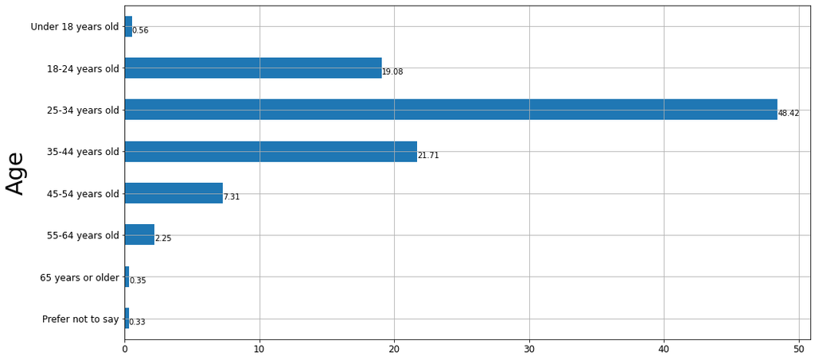

```python
df_plot = (
    df
    [['Age','MainBranch']]
    [df.MainBranch=='I am a developer by profession']
    .stb.freq(['Age'])
)

fig, ax = plt.subplots(figsize=(16,8))
df_plot = df_plot.iloc[:, [0, 2]].set_index('Age')
index = ['Prefer not to say',
         '65 years or older',
         '55-64 years old',
         '45-54 years old',
         '35-44 years old',
         '25-34 years old',
         '18-24 years old',
         'Under 18 years old']
df_plot = df_plot.reindex(index=index)
df_plot.plot.barh(ax = ax, legend=False, grid=True, fontsize=12)
for p in ax.patches:
    w = p.get_width()
    ax.annotate(f'{w:.2f}', (w * 1., p.get_y() + 0.1))
ax.set_ylabel(ylabel='Age', fontsize=30)
plt.show()
```

### Gender

```python
# Which of the following describe you, if any?
data = df['Gender'].copy()
data = data.str.split(';', expand=True).stack().reset_index(drop=True)
pd.DataFrame(data, columns=['Gender']).stb.freq(['Gender']).iloc[:2]
```

|  | Gender | count | percent | cumulative_count | cumulative_percent |
| --- | --- | --- | --- | --- | --- |
| 0 | Man | 75428 | 90.70 | 75428 | 90.70 |
| 1 | Woman | 4372 | 5.26 | 79800 | 95.95 |

```python
(
    df
    [['Gender','MainBranch']]
    [df.MainBranch=='I am a developer by profession']
    .stb.freq(['Gender'])
    .iloc[:2]
)
```

|  | Gender | count | percent | cumulative_count | cumulative_percent |
| --- | --- | --- | --- | --- | --- |
| 0 | Man | 52938 | 92.12 | 52938 | 92.12 |
| 1 | Woman | 2599 | 4.52 | 55537 | 96.65 |

`91% of all respondents and 92% of professional developers identify as a man.`

```python
(
    df
    [['ResponseId','Gender','Country']]
    .groupby(['Country','Gender'])
    .count()
    .unstack(level=-1)
    .iloc[:,-3]
    .dropna(how='any')
    .sort_values(ascending=False)
    [:5]
)
```

```
Country
United States of America                               65.00
Germany                                                12.00
United Kingdom of Great Britain and Northern Ireland    9.00
Canada                                                  6.00
Norway                                                  5.00
Name: (ResponseId, Woman;Non-binary, genderqueer, or gender non-conforming), dtype: float64
```

### Transgender

```python
# Do you identify as transgender?
df.stb.freq(['Trans'])
```

|  | Trans | count | percent | cumulative_count | cumulative_percent |
| --- | --- | --- | --- | --- | --- |
| 0 | No | 77275 | 95.78 | 77275 | 95.78 |
| 1 | Prefer not to say | 1764 | 2.19 | 79039 | 97.97 |
| 2 | Yes | 1035 | 1.28 | 80074 | 99.25 |
| 3 | Or, in your own words: | 604 | 0.75 | 80678 | 100.00 |

```python
# Trans, MainBranch=='I am a developer by profession'
(
    df
    [['Trans','MainBranch']]
    [df['Trans']=='Yes']
    .value_counts(normalize=True)
    .mul(100)
    .round()
)
```

```
Trans  MainBranch
Yes    I am a developer by profession                                                  55.00
       I am a student who is learning to code                                          20.00
       I code primarily as a hobby                                                     15.00
       I am not primarily a developer, but I write code sometimes as part of my work    6.00
       I used to be a developer by profession, but no longer am                         3.00
       None of these                                                                    2.00
dtype: float64
```

`Only 1.28% of respondents identify as transgender, 55% of them being professional developers.`